pip install dataprep

# Global Youtube Statistic Analysis

# I. Introduction

In today's digital era, YouTube has transcended its origins as a platform for user-generated content to become a global phenomenon, revolutionizing the way we consume information and entertainment. With an ever-expanding universe of creators, audiences, and content, YouTube is a dynamic ecosystem that shapes modern media, entertainment, and marketing landscapes. This analysis endeavors to explore the multifaceted world of YouTube through a comprehensive dataset, which includes details on top creators' subscriber counts, video views, upload frequency, country of origin, earnings, and more.

The significance of this endeavor lies in unraveling the secrets behind YouTube's immense success, the strategies employed by top creators, and the emerging trends that influence content creation and audience engagement. By leveraging this rich dataset, we aim to provide actionable insights that can drive decision-making, foster innovation, and enable stakeholders to tap into the full potential of the YouTube platform.

# II. Analysis

## 1.Business Objective/Problem

Through the dataset including top 10 Youtubers in the world, we will conduct a deep explorationary data analysis to get insights that can help us give the best answers to the following business questions and satisfy our business objectives:

1. What are top 10 Youtubers who have the highest amount of views?
2. Does it mean that a Youtube channel owning a high number of subscribers is associated with a high amount of views?
3. Does it mean that a Youtube channel owning a high total of uploads will lead to a high number of subscribers and amount of views
4. What are some categories of Youtube channels which have the most uploads?
5. How many channels are there in each category?
6. What are some Youtube user trends throughout the number of subscribers and the amount of views in each category?
7. What are some interesting interaction and behaviors of users in those catgories. (measured by total views of per user)
8. Does the content (key terms) in the name of YouTube channels affect user views?
9. What countries do those top 10 youtubers come from?

   9.1 What is the unemployment rate?

   9.2 What is the rate of high education attainment of each country?

   9.3 What is the rate of urban population in each country?
10. When were most successful Youtube Channel created ?
11. What are the trending content creactivity of each chanel over the time?
12. What is the posibility of generating average earnings per month in each category?
13. Does it mean that a higher amount of views will lead to a higher earning?

## 2. Data Preparing

Key Features: Rank: Position of the YouTube channel based on the number of subscribers Youtuber

Population: Name of the YouTube channel

subscribers: Number of subscribers to the channel

video views : Total views across all videos on the channel

category : Category or niche of the channel

Title : Title of the YouTube channel

uploads : Total number of videos uploaded on the channel

Country : Country where the YouTube channel originates

Abbreviation : Abbreviation of the country

channel_type : Type of the YouTube channel (e.g., individual, brand)

video_views_rank : Ranking of the channel based on total video views

country_rank : Ranking of the channel based on the number of subscribers within its country

channel_type_rank : Ranking of the channel based on its type (individual or brand)

video_views_for_the_last_30_days : Total video views in the last 30 days

lowest_monthly_earnings : Lowest estimated monthly earnings from the channel

highest_monthly_earnings : Highest estimated monthly earnings from the channel

lowest_yearly_earnings : Lowest estimated yearly earnings from the channel

highest_yearly_earnings : Highest estimated yearly earnings from the channel

subscribers_for_last_30_days : Number of new subscribers gained in the last 30

days created_year : Year when the YouTube channel was created

created_month : Month when the YouTube channel was created

created_date : Exact date of the YouTube channel's creation

Gross tertiary education enrollment (%) : Percentage of the population enrolled in tertiary education in the country

Population: Total population of the country

Unemployment rate : Unemployment rate in the country

Urban_population : Percentage of the population living in urban areas

Latitude : Latitude coordinate of the country's location

Longitude : Longitude coordinate of the country's location

```python
import numpy as np
import pandas as pd
import matplotlib.pyplot as plt
import seaborn as sb
from dataprep.datasets import load_dataset
from dataprep.eda import create_report, plot
import scipy
import warnings
warnings.filterwarnings('ignore')
from dataprep.clean import clean_headers
from scipy import stats
import re
from wordcloud import WordCloud, STOPWORDS
np.set_printoptions(suppress=True)
```

```python
data = pd.read_csv('Documents/Data Analytics Projects/Global YouTube Statistics.csv', encoding='latin-1') #'ISO-8859-1'
```

```python
data.reset_index(drop= True, inplace= True)
```

```python
data
```

|  | rank | Youtuber | subscribers | video views | category | Title | uploads | Country | Abbreviation | channel_type | ... | subscribers_for_last_30_days | created_year | created_month | created_date | Gross tertiary education enrollment (%) | Population | Unemployment rate | Urban_population | Latitude | Longitude |
| --- | --- | --- | --- | --- | --- | --- | --- | --- | --- | --- | --- | --- | --- | --- | --- | --- | --- | --- | --- | --- | --- |
| 0 | 1 | T-Series | 245000000 | 2.280000e+11 | Music | T-Series | 20082 | India | IN | Music | ... | 2000000.0 | 2006.0 | Mar | 13.0 | 28.1 | 1.366418e+09 | 5.36 | 471031528.0 | 20.593684 | 78.962880 |
| 1 | 2 | YouTube Movies | 170000000 | 0.000000e+00 | Film & Animation | youtubemovies | 1 | United States | US | Games | ... | NaN | 2006.0 | Mar | 5.0 | 88.2 | 3.282395e+08 | 14.70 | 270663028.0 | 37.090240 | -95.712891 |
| 2 | 3 | MrBeast | 166000000 | 2.836884e+10 | Entertainment | MrBeast | 741 | United States | US | Entertainment | ... | 8000000.0 | 2012.0 | Feb | 20.0 | 88.2 | 3.282395e+08 | 14.70 | 270663028.0 | 37.090240 | -95.712891 |
| 3 | 4 | Cocomelon - Nursery Rhymes | 162000000 | 1.640000e+11 | Education | Cocomelon - Nursery Rhymes | 966 | United States | US | Education | ... | 1000000.0 | 2006.0 | Sep | 1.0 | 88.2 | 3.282395e+08 | 14.70 | 270663028.0 | 37.090240 | -95.712891 |
| 4 | 5 | SET India | 159000000 | 1.480000e+11 | Shows | SET India | 116536 | India | IN | Entertainment | ... | 1000000.0 | 2006.0 | Sep | 20.0 | 28.1 | 1.366418e+09 | 5.36 | 471031528.0 | 20.593684 | 78.962880 |
| ... | ... | ... | ... | ... | ... | ... | ... | ... | ... | ... | ... | ... | ... | ... | ... | ... | ... | ... | ... | ... | ... |
| 990 | 991 | Natan por Aï¿ | 12300000 | 9.029610e+09 | Sports | Natan por Aï¿ | 1200 | Brazil | BR | Entertainment | ... | 700000.0 | 2017.0 | Feb | 12.0 | 51.3 | 2.125594e+08 | 12.08 | 183241641.0 | -14.235004 | -51.925280 |
| 991 | 992 | Free Fire India Official | 12300000 | 1.674410e+09 | People & Blogs | Free Fire India Official | 1500 | India | IN | Games | ... | 300000.0 | 2018.0 | Sep | 14.0 | 28.1 | 1.366418e+09 | 5.36 | 471031528.0 | 20.593684 | 78.962880 |
| 992 | 993 | Panda | 12300000 | 2.214684e+09 | NaN | HybridPanda | 2452 | United Kingdom | GB | Games | ... | 1000.0 | 2006.0 | Sep | 11.0 | 60.0 | 6.683440e+07 | 3.85 | 55908316.0 | 55.378051 | -3.435973 |
| 993 | 994 | RobTopGames | 12300000 | 3.741235e+08 | Gaming | RobTopGames | 39 | Sweden | SE | Games | ... | 100000.0 | 2012.0 | May | 9.0 | 67.0 | 1.028545e+07 | 6.48 | 9021165.0 | 60.128161 | 18.643501 |
| 994 | 995 | Make Joke Of | 12300000 | 2.129774e+09 | Comedy | Make Joke Of | 62 | India | IN | Comedy | ... | 100000.0 | 2017.0 | Aug | 1.0 | 28.1 | 1.366418e+09 | 5.36 | 471031528.0 | 20.593684 | 78.962880 |

995 rows × 28 columns

```python
data.shape
```

```
(995, 28)
```

```python
data.info()
```

```
<class 'pandas.core.frame.DataFrame'>
RangeIndex: 995 entries, 0 to 994
Data columns (total 28 columns):
 #   Column                                   Non-Null Count  Dtype
---  ------                                   --------------  -----
 0   rank                                     995 non-null    int64
 1   Youtuber                                 995 non-null    object
 2   subscribers                              995 non-null    int64
 3   video views                              995 non-null    float64
 4   category                                 949 non-null    object
 5   Title                                    995 non-null    object
 6   uploads                                  995 non-null    int64
 7   Country                                  873 non-null    object
 8   Abbreviation                             873 non-null    object
 9   channel_type                             965 non-null    object
```

[output cut: 20 more lines]

```python
data.columns
```

```
Index(['rank', 'Youtuber', 'subscribers', 'video views', 'category', 'Title',
       'uploads', 'Country', 'Abbreviation', 'channel_type',
       'video_views_rank', 'country_rank', 'channel_type_rank',
       'video_views_for_the_last_30_days', 'lowest_monthly_earnings',
       'highest_monthly_earnings', 'lowest_yearly_earnings',
       'highest_yearly_earnings', 'subscribers_for_last_30_days',
       'created_year', 'created_month', 'created_date',
       'Gross tertiary education enrollment (%)', 'Population',
       'Unemployment rate', 'Urban_population', 'Latitude', 'Longitude'],
      dtype='object')
```

```python
#clean columns in the dataset
data.columns = data.columns.str.replace('_',' ')
data.columns = data.columns.str.title()
data.columns
```

```
Index(['Rank', 'Youtuber', 'Subscribers', 'Video Views', 'Category', 'Title',
       'Uploads', 'Country', 'Abbreviation', 'Channel Type',
       'Video Views Rank', 'Country Rank', 'Channel Type Rank',
       'Video Views For The Last 30 Days', 'Lowest Monthly Earnings',
       'Highest Monthly Earnings', 'Lowest Yearly Earnings',
       'Highest Yearly Earnings', 'Subscribers For Last 30 Days',
       'Created Year', 'Created Month', 'Created Date',
       'Gross Tertiary Education Enrollment (%)', 'Population',
       'Unemployment Rate', 'Urban Population', 'Latitude', 'Longitude'],
      dtype='object')
```

## 3. Select variables to analyst

```python
youtube = data[['Youtuber', 'Subscribers', 'Video Views', 'Uploads', 'Category', 'Country', 'Abbreviation', 'Lowest Monthly Earnings',
                'Highest Monthly Earnings', 'Gross Tertiary Education Enrollment (%)', 'Unemployment Rate',
                'Population','Urban Population','Created Year']]

youtube.head(10)
```

|  | Youtuber | Subscribers | Video Views | Uploads | Category | Country | Abbreviation | Lowest Monthly Earnings | Highest Monthly Earnings | Gross Tertiary Education Enrollment (%) | Unemployment Rate | Population | Urban Population | Created Year |
| --- | --- | --- | --- | --- | --- | --- | --- | --- | --- | --- | --- | --- | --- | --- |
| 0 | T-Series | 245000000 | 2.280000e+11 | 20082 | Music | India | IN | 564600.0 | 9000000.00 | 28.1 | 5.36 | 1.366418e+09 | 471031528.0 | 2006.0 |
| 1 | YouTube Movies | 170000000 | 0.000000e+00 | 1 | Film & Animation | United States | US | 0.0 | 0.05 | 88.2 | 14.70 | 3.282395e+08 | 270663028.0 | 2006.0 |
| 2 | MrBeast | 166000000 | 2.836884e+10 | 741 | Entertainment | United States | US | 337000.0 | 5400000.00 | 88.2 | 14.70 | 3.282395e+08 | 270663028.0 | 2012.0 |
| 3 | Cocomelon - Nursery Rhymes | 162000000 | 1.640000e+11 | 966 | Education | United States | US | 493800.0 | 7900000.00 | 88.2 | 14.70 | 3.282395e+08 | 270663028.0 | 2006.0 |
| 4 | SET India | 159000000 | 1.480000e+11 | 116536 | Shows | India | IN | 455900.0 | 7300000.00 | 28.1 | 5.36 | 1.366418e+09 | 471031528.0 | 2006.0 |
| 5 | Music | 119000000 | 0.000000e+00 | 0 | NaN | NaN | NaN | 0.0 | 0.00 | NaN | NaN | NaN | NaN | 2013.0 |
| 6 | ýýý Kids Diana Show | 112000000 | 9.324704e+10 | 1111 | People & Blogs | United States | US | 182900.0 | 2900000.00 | 88.2 | 14.70 | 3.282395e+08 | 270663028.0 | 2015.0 |
| 7 | PewDiePie | 111000000 | 2.905804e+10 | 4716 | Gaming | Japan | JP | 9800.0 | 156700.00 | 63.2 | 2.29 | 1.262266e+08 | 115782416.0 | 2010.0 |
| 8 | Like Nastya | 106000000 | 9.047906e+10 | 493 | People & Blogs | Russia | RU | 12200.0 | 195800.00 | 81.9 | 4.59 | 1.443735e+08 | 107683889.0 | 2016.0 |
| 9 | Vlad and Niki | 98900000 | 7.718017e+10 | 574 | Entertainment | United States | US | 145100.0 | 2300000.00 | 88.2 | 14.70 | 3.282395e+08 | 270663028.0 | 2018.0 |

## 4. Data pre-processing

```python
#remove special characters

pattern = r'[^a-zA-Z0-9\s.,!?&\'-]'
```

```python
#Youtuber feature
youtube['Youtuber'] = youtube['Youtuber'].apply(lambda x: re.sub(pattern, '', x))
youtube['Youtuber'] = youtube['Youtuber'].str.strip()
youtube['Youtuber'] = youtube['Youtuber'].str.lstrip('- ')
```

```python
#check special characters in Youtuber feature
filter_youtuber_rows = youtube['Youtuber'].str.contains(pattern, regex = True)
filter_youtuber_rows_results = filter_youtuber_rows[filter_youtuber_rows == True]
print("Youtuber's special characters:",filter_youtuber_rows_results)
```

```
Youtuber's special characters: Series([], Name: Youtuber, dtype: bool)
```

```python
youtube.head()
```

|  | Youtuber | Subscribers | Video Views | Uploads | Category | Country | Abbreviation | Lowest Monthly Earnings | Highest Monthly Earnings | Gross Tertiary Education Enrollment (%) | Unemployment Rate | Population | Urban Population | Created Year |
| --- | --- | --- | --- | --- | --- | --- | --- | --- | --- | --- | --- | --- | --- | --- |
| 0 | T-Series | 245000000 | 2.280000e+11 | 20082 | Music | India | IN | 564600.0 | 9000000.00 | 28.1 | 5.36 | 1.366418e+09 | 471031528.0 | 2006.0 |
| 1 | YouTube Movies | 170000000 | 0.000000e+00 | 1 | Film & Animation | United States | US | 0.0 | 0.05 | 88.2 | 14.70 | 3.282395e+08 | 270663028.0 | 2006.0 |
| 2 | MrBeast | 166000000 | 2.836884e+10 | 741 | Entertainment | United States | US | 337000.0 | 5400000.00 | 88.2 | 14.70 | 3.282395e+08 | 270663028.0 | 2012.0 |
| 3 | Cocomelon - Nursery Rhymes | 162000000 | 1.640000e+11 | 966 | Education | United States | US | 493800.0 | 7900000.00 | 88.2 | 14.70 | 3.282395e+08 | 270663028.0 | 2006.0 |
| 4 | SET India | 159000000 | 1.480000e+11 | 116536 | Shows | India | IN | 455900.0 | 7300000.00 | 28.1 | 5.36 | 1.366418e+09 | 471031528.0 | 2006.0 |

```python
youtube.info()
```

```
<class 'pandas.core.frame.DataFrame'>
RangeIndex: 995 entries, 0 to 994
Data columns (total 14 columns):
 #   Column                                   Non-Null Count  Dtype
---  ------                                   --------------  -----
 0   Youtuber                                 995 non-null    object
 1   Subscribers                              995 non-null    int64
 2   Video Views                              995 non-null    float64
 3   Uploads                                  995 non-null    int64
 4   Category                                 949 non-null    object
 5   Country                                  873 non-null    object
 6   Abbreviation                             873 non-null    object
 7   Lowest Monthly Earnings                  995 non-null    float64
 8   Highest Monthly Earnings                 995 non-null    float64
 9   Gross Tertiary Education Enrollment (%)  872 non-null    float64
 10  Unemployment Rate                        872 non-null    float64
 11  Population                               872 non-null    float64
 12  Urban Population                         872 non-null    float64
 13  Created Year                             990 non-null    float64
dtypes: float64(8), int64(2), object(4)
memory usage: 109.0+ KB
```

```python
youtube.columns
```

```
Index(['Youtuber', 'Subscribers', 'Video Views', 'Uploads', 'Category',
       'Country', 'Abbreviation', 'Lowest Monthly Earnings',
       'Highest Monthly Earnings', 'Gross Tertiary Education Enrollment (%)',
       'Unemployment Rate', 'Population', 'Urban Population', 'Created Year'],
      dtype='object')
```

```python
#Remove data null in column 'Created Year'
youtube = youtube.dropna(subset= ['Created Year'])

youtube['Created Year'] = youtube['Created Year'].astype('object')

# youtube.info()
# youtube['Created Year'] = pd.to_datetime(youtube['Created Year'], format= '%Y')
youtube.info()
```

```
<class 'pandas.core.frame.DataFrame'>
Int64Index: 990 entries, 0 to 994
Data columns (total 14 columns):
 #   Column                                   Non-Null Count  Dtype
---  ------                                   --------------  -----
 0   Youtuber                                 990 non-null    object
 1   Subscribers                              990 non-null    int64
 2   Video Views                              990 non-null    float64
 3   Uploads                                  990 non-null    int64
 4   Category                                 944 non-null    object
 5   Country                                  870 non-null    object
 6   Abbreviation                             870 non-null    object
 7   Lowest Monthly Earnings                  990 non-null    float64
 8   Highest Monthly Earnings                 990 non-null    float64
 9   Gross Tertiary Education Enrollment (%)  869 non-null    float64
 10  Unemployment Rate                        869 non-null    float64
 11  Population                               869 non-null    float64
 12  Urban Population                         869 non-null    float64
 13  Created Year                             990 non-null    object
dtypes: float64(7), int64(2), object(5)
memory usage: 116.0+ KB
```

```python
#Check Created Year data
youtube['Created Year'].unique()
```

```
array([2006.0, 2012.0, 2013.0, 2015.0, 2010.0, 2016.0, 2018.0, 2014.0,
       2007.0, 2020.0, 2008.0, 2005.0, 2011.0, 2009.0, 2017.0, 2021.0,
       1970.0, 2019.0, 2022.0], dtype=object)
```

```python
#Check Created Year is 1970
youtube[youtube['Created Year'] == 1970]
```

|  | Youtuber | Subscribers | Video Views | Uploads | Category | Country | Abbreviation | Lowest Monthly Earnings | Highest Monthly Earnings | Gross Tertiary Education Enrollment (%) | Unemployment Rate | Population | Urban Population | Created Year |
| --- | --- | --- | --- | --- | --- | --- | --- | --- | --- | --- | --- | --- | --- | --- |
| 101 | YouTube | 36300000 | 3.010785e+09 | 744 | News & Politics | United States | US | 5300.0 | 84400.0 | 88.2 | 14.7 | 328239523.0 | 270663028.0 | 1970.0 |

Youtube was established on February 14, 2005. I can see a mistake in the process of establishing this Youtube channel.

This may be the channel representing the Youtube platform, I will temporarily replace the data from the time this channel was established until the day Youtube was born.

```python
youtube[youtube['Youtuber'] == 'YouTube'] = youtube[youtube['Youtuber'] == 'YouTube'].replace(1970, 2005)

youtube[youtube['Youtuber'] == 'YouTube']
```

|  | Youtuber | Subscribers | Video Views | Uploads | Category | Country | Abbreviation | Lowest Monthly Earnings | Highest Monthly Earnings | Gross Tertiary Education Enrollment (%) | Unemployment Rate | Population | Urban Population | Created Year |
| --- | --- | --- | --- | --- | --- | --- | --- | --- | --- | --- | --- | --- | --- | --- |
| 101 | YouTube | 36300000 | 3.010785e+09 | 744 | News & Politics | United States | US | 5300.0 | 84400.0 | 88.2 | 14.7 | 328239523.0 | 270663028.0 | 2005 |

```python
youtube['Created Year'].unique()
```

```
array([2006.0, 2012.0, 2013.0, 2015.0, 2010.0, 2016.0, 2018.0, 2014.0,
       2007.0, 2020.0, 2008.0, 2005.0, 2011.0, 2009.0, 2017.0, 2021.0,
       2019.0, 2022.0], dtype=object)
```

```python
#After remomved characters, we will remove some blanks data in column 'Youtuber'. Let's check it
blanks_data_youtuber = youtube[youtube['Youtuber'] == '']
blanks_data_youtuber
```

|  | Youtuber | Subscribers | Video Views | Uploads | Category | Country | Abbreviation | Lowest Monthly Earnings | Highest Monthly Earnings | Gross Tertiary Education Enrollment (%) | Unemployment Rate | Population | Urban Population | Created Year |
| --- | --- | --- | --- | --- | --- | --- | --- | --- | --- | --- | --- | --- | --- | --- |
| 64 |  | 43200000 | 3.645873e+10 | 1478 | Film & Animation | Russia | RU | 75900.0 | 1200000.0 | 81.9 | 4.59 | 144373535.0 | 107683889.0 | 2011.0 |
| 161 |  | 30400000 | 1.799996e+10 | 532 | NaN | United States | US | 30700.0 | 491700.0 | 88.2 | 14.70 | 328239523.0 | 270663028.0 | 2018.0 |
| 433 |  | 19000000 | 4.924054e+09 | 60 | Education | United States | US | 5400.0 | 86300.0 | 88.2 | 14.70 | 328239523.0 | 270663028.0 | 2018.0 |
| 447 |  | 18800000 | 9.594189e+09 | 530 | Entertainment | Ukraine | UA | 17000.0 | 272000.0 | 82.7 | 8.88 | 44385155.0 | 30835699.0 | 2014.0 |
| 561 |  | 16500000 | 2.440934e+09 | 421 | Entertainment | United States | US | 5500.0 | 87800.0 | 88.2 | 14.70 | 328239523.0 | 270663028.0 | 2014.0 |
| 606 |  | 15900000 | 1.845330e+09 | 0 | People & Blogs | Russia | RU | 0.0 | 0.0 | 81.9 | 4.59 | 144373535.0 | 107683889.0 | 2017.0 |
| 632 |  | 15500000 | 8.265130e+09 | 1021 | Shows | Saudi Arabia | SA | 33800.0 | 540100.0 | 68.0 | 5.93 | 34268528.0 | 28807838.0 | 2017.0 |
| 700 |  | 14900000 | 4.390980e+05 | 1 | People & Blogs | Russia | RU | 2.0 | 31.0 | 81.9 | 4.59 | 144373535.0 | 107683889.0 | 2008.0 |
| 707 |  | 14800000 | 7.018015e+09 | 2387 | Howto & Style | Ukraine | UA | 11800.0 | 188500.0 | 82.7 | 8.88 | 44385155.0 | 30835699.0 | 2015.0 |
| 714 |  | 14700000 | 2.230986e+09 | 1385 | Entertainment | Saudi Arabia | SA | 673.0 | 10800.0 | 68.0 | 5.93 | 34268528.0 | 28807838.0 | 2016.0 |
| 752 |  | 14400000 | 6.001543e+08 | 364 | Entertainment | South Korea | KR | 342.0 | 5500.0 | 94.3 | 4.15 | 51709098.0 | 42106719.0 | 2017.0 |
| 784 |  | 14100000 | 3.920221e+09 | 65 | Entertainment | NaN | NaN | 5.0 | 81.0 | NaN | NaN | NaN | NaN | 2017.0 |
| 795 |  | 14000000 | 7.719743e+09 | 2210 | Gaming | Russia | RU | 37600.0 | 602300.0 | 81.9 | 4.59 | 144373535.0 | 107683889.0 | 2013.0 |
| 810 |  | 13900000 | 8.451755e+09 | 504 | NaN | United States | US | 28600.0 | 457000.0 | 88.2 | 14.70 | 328239523.0 | 270663028.0 | 2018.0 |
| 866 |  | 13300000 | 6.482687e+09 | 608 | People & Blogs | Russia | RU | 22600.0 | 361000.0 | 81.9 | 4.59 | 144373535.0 | 107683889.0 | 2015.0 |
| 920 |  | 12900000 | 5.585085e+09 | 1255 | Shows | Ukraine | UA | 17800.0 | 284500.0 | 82.7 | 8.88 | 44385155.0 | 30835699.0 | 2014.0 |

```python
# Remove rows from with blank Youtuber as these are channels with only special characters
youtube = youtube.drop(blanks_data_youtuber.index)
youtube.reset_index(drop= True, inplace= True)
youtube[youtube['Youtuber'] == '']
```

|  | Youtuber | Subscribers | Video Views | Uploads | Category | Country | Abbreviation | Lowest Monthly Earnings | Highest Monthly Earnings | Gross Tertiary Education Enrollment (%) | Unemployment Rate | Population | Urban Population | Created Year |
| --- | --- | --- | --- | --- | --- | --- | --- | --- | --- | --- | --- | --- | --- | --- |

```python
#Check duplicate data
youtube.duplicated().sum()
```

```
0
```

```python
#Check zero data video views
zero_views = youtube[youtube['Video Views'] == 0]
zero_views
```

|  | Youtuber | Subscribers | Video Views | Uploads | Category | Country | Abbreviation | Lowest Monthly Earnings | Highest Monthly Earnings | Gross Tertiary Education Enrollment (%) | Unemployment Rate | Population | Urban Population | Created Year |
| --- | --- | --- | --- | --- | --- | --- | --- | --- | --- | --- | --- | --- | --- | --- |
| 1 | YouTube Movies | 170000000 | 0.0 | 1 | Film & Animation | United States | US | 0.0 | 0.05 | 88.2 | 14.7 | 328239523.0 | 270663028.0 | 2006.0 |
| 5 | Music | 119000000 | 0.0 | 0 | NaN | NaN | NaN | 0.0 | 0.00 | NaN | NaN | NaN | NaN | 2013.0 |
| 12 | Gaming | 93600000 | 0.0 | 0 | NaN | NaN | NaN | 0.0 | 0.00 | NaN | NaN | NaN | NaN | 2013.0 |
| 18 | Sports | 75000000 | 0.0 | 3 | NaN | United States | US | 0.0 | 0.06 | 88.2 | 14.7 | 328239523.0 | 270663028.0 | 2006.0 |
| 101 | News | 36300000 | 0.0 | 0 | NaN | NaN | NaN | 0.0 | 0.00 | NaN | NaN | NaN | NaN | 2013.0 |
| 171 | Popular on YouTube | 29300000 | 0.0 | 3 | NaN | NaN | NaN | 0.0 | 0.00 | NaN | NaN | NaN | NaN | 2017.0 |
| 357 | Minecraft - Topic | 20900000 | 0.0 | 0 | NaN | NaN | NaN | 0.0 | 0.00 | NaN | NaN | NaN | NaN | 2013.0 |
| 584 | Live | 16100000 | 0.0 | 0 | NaN | NaN | NaN | 0.0 | 0.00 | NaN | NaN | NaN | NaN | 2015.0 |

There are some YouTube channels which have 0 views, which appear to be YouTube topics & not valid channels, for the purpose of this analysis these rows will be removed

```python
#Remove zero data video views
youtube = youtube.drop(zero_views.index)
youtube.reset_index(drop= True, inplace= True)
youtube[youtube['Video Views'] == 0]
```

|  | Youtuber | Subscribers | Video Views | Uploads | Category | Country | Abbreviation | Lowest Monthly Earnings | Highest Monthly Earnings | Gross Tertiary Education Enrollment (%) | Unemployment Rate | Population | Urban Population | Created Year |
| --- | --- | --- | --- | --- | --- | --- | --- | --- | --- | --- | --- | --- | --- | --- |

```python
youtube.shape
```

```
(966, 14)
```

```python
#Check null/nan data
youtube.isnull().sum()
```

```
Youtuber                                     0
Subscribers                                  0
Video Views                                  0
Uploads                                      0
Category                                    37
Country                                    113
Abbreviation                               113
Lowest Monthly Earnings                      0
Highest Monthly Earnings                     0
Gross Tertiary Education Enrollment (%)    114
Unemployment Rate                          114
Population                                 114
Urban Population                           114
Created Year                                 0
dtype: int64
```

```python
#There are lots of missing value in the category variables
#We will group all missing values to 'Other'

#Select category columns
categorical_variables = youtube.select_dtypes(include= 'O').columns

#Replace object datatype column missing values with 'Other'
youtube[categorical_variables] = youtube[categorical_variables].fillna('Other')
```

```python
#check missing value
youtube.isna().sum()
```

```
Youtuber                                     0
Subscribers                                  0
Video Views                                  0
Uploads                                      0
Category                                     0
Country                                      0
Abbreviation                                 0
Lowest Monthly Earnings                      0
Highest Monthly Earnings                     0
Gross Tertiary Education Enrollment (%)    114
Unemployment Rate                          114
Population                                 114
Urban Population                           114
Created Year                                 0
dtype: int64
```

```python
youtube.info()
```

```
<class 'pandas.core.frame.DataFrame'>
RangeIndex: 966 entries, 0 to 965
Data columns (total 14 columns):
 #   Column                                   Non-Null Count  Dtype
---  ------                                   --------------  -----
 0   Youtuber                                 966 non-null    object
 1   Subscribers                              966 non-null    int64
 2   Video Views                              966 non-null    float64
 3   Uploads                                  966 non-null    int64
 4   Category                                 966 non-null    object
 5   Country                                  966 non-null    object
 6   Abbreviation                             966 non-null    object
 7   Lowest Monthly Earnings                  966 non-null    float64
 8   Highest Monthly Earnings                 966 non-null    float64
 9   Gross Tertiary Education Enrollment (%)  852 non-null    float64
 10  Unemployment Rate                        852 non-null    float64
 11  Population                               852 non-null    float64
 12  Urban Population                         852 non-null    float64
 13  Created Year                             966 non-null    float64
dtypes: float64(8), int64(2), object(4)
memory usage: 105.8+ KB
```

```python
#Youtube is not null
youtube_not_null = youtube.dropna(subset= ['Gross Tertiary Education Enrollment (%)','Unemployment Rate', 'Population', 'Urban Population'])
```

```python
#Mean Education Enrollment
mean_edu = round(youtube_not_null['Gross Tertiary Education Enrollment (%)'].mean(),1)
print('Mean Gross Tertiary Education Enrollment:', mean_edu)

#Mean Unemployment Rate
mean_unemp = round(youtube_not_null['Unemployment Rate'].mean(),1)
print('Mean Unemployment Rate:', mean_unemp)

#Mean Population
mean_popu = round(youtube_not_null['Population'].mean(),0)
print('Mean Population:', mean_popu)

#Mean Urban Population
mean_urban = round(youtube_not_null['Urban Population'].mean(),0)
print('Mean Urban Population:', mean_urban)
```

```
Mean Gross Tertiary Education Enrollment: 63.2
Mean Unemployment Rate: 9.3
Mean Population: 436369043.0
Mean Urban Population: 226156206.0
```

```python
#There are lots of missing value in the numeric variables
#Replace object datatype column missing values with Mean Values
youtube['Gross Tertiary Education Enrollment (%)'] = youtube['Gross Tertiary Education Enrollment (%)'].fillna(mean_edu)

youtube['Unemployment Rate'] = youtube['Unemployment Rate'].fillna(mean_unemp)

youtube['Population'] = youtube['Population'].fillna(mean_popu)

youtube['Urban Population'] = youtube['Urban Population'].fillna(mean_urban)
```

```python
youtube.info()
```

```
<class 'pandas.core.frame.DataFrame'>
RangeIndex: 966 entries, 0 to 965
Data columns (total 14 columns):
 #   Column                                   Non-Null Count  Dtype
---  ------                                   --------------  -----
 0   Youtuber                                 966 non-null    object
 1   Subscribers                              966 non-null    int64
 2   Video Views                              966 non-null    float64
 3   Uploads                                  966 non-null    int64
 4   Category                                 966 non-null    object
 5   Country                                  966 non-null    object
 6   Abbreviation                             966 non-null    object
 7   Lowest Monthly Earnings                  966 non-null    float64
 8   Highest Monthly Earnings                 966 non-null    float64
 9   Gross Tertiary Education Enrollment (%)  966 non-null    float64
 10  Unemployment Rate                        966 non-null    float64
 11  Population                               966 non-null    float64
 12  Urban Population                         966 non-null    float64
 13  Created Year                             966 non-null    float64
dtypes: float64(8), int64(2), object(4)
memory usage: 105.8+ KB
```

```python
# Convert several float data typescolumns to integars
youtube = youtube.astype({ 'Video Views': 'int64',
                          'Created Year': 'int64',
                          'Population': 'int64',
                          'Urban Population': 'int64' })

# Validate results of datatype change
youtube.info()
```

```
<class 'pandas.core.frame.DataFrame'>
RangeIndex: 966 entries, 0 to 965
Data columns (total 14 columns):
 #   Column                                   Non-Null Count  Dtype
---  ------                                   --------------  -----
 0   Youtuber                                 966 non-null    object
 1   Subscribers                              966 non-null    int64
 2   Video Views                              966 non-null    int64
 3   Uploads                                  966 non-null    int64
 4   Category                                 966 non-null    object
 5   Country                                  966 non-null    object
 6   Abbreviation                             966 non-null    object
 7   Lowest Monthly Earnings                  966 non-null    float64
 8   Highest Monthly Earnings                 966 non-null    float64
 9   Gross Tertiary Education Enrollment (%)  966 non-null    float64
 10  Unemployment Rate                        966 non-null    float64
 11  Population                               966 non-null    int64
 12  Urban Population                         966 non-null    int64
 13  Created Year                             966 non-null    int64
dtypes: float64(4), int64(6), object(4)
memory usage: 105.8+ KB
```

```python
#sorting the dataframe and resetting index (by 'Subscribers)
youtube = youtube.sort_values(by = 'Subscribers', ascending= False).reset_index(drop= True)
youtube
```

|  | Youtuber | Subscribers | Video Views | Uploads | Category | Country | Abbreviation | Lowest Monthly Earnings | Highest Monthly Earnings | Gross Tertiary Education Enrollment (%) | Unemployment Rate | Population | Urban Population | Created Year |
| --- | --- | --- | --- | --- | --- | --- | --- | --- | --- | --- | --- | --- | --- | --- |
| 0 | T-Series | 245000000 | 228000000000 | 20082 | Music | India | IN | 564600.0 | 9000000.0 | 28.1 | 5.36 | 1366417754 | 471031528 | 2006 |
| 1 | MrBeast | 166000000 | 28368841870 | 741 | Entertainment | United States | US | 337000.0 | 5400000.0 | 88.2 | 14.70 | 328239523 | 270663028 | 2012 |
| 2 | Cocomelon - Nursery Rhymes | 162000000 | 164000000000 | 966 | Education | United States | US | 493800.0 | 7900000.0 | 88.2 | 14.70 | 328239523 | 270663028 | 2006 |
| 3 | SET India | 159000000 | 148000000000 | 116536 | Shows | India | IN | 455900.0 | 7300000.0 | 28.1 | 5.36 | 1366417754 | 471031528 | 2006 |
| 4 | Kids Diana Show | 112000000 | 93247040539 | 1111 | People & Blogs | United States | US | 182900.0 | 2900000.0 | 88.2 | 14.70 | 328239523 | 270663028 | 2015 |
| ... | ... | ... | ... | ... | ... | ... | ... | ... | ... | ... | ... | ... | ... | ... |
| 961 | Natan por A | 12300000 | 9029609749 | 1200 | Sports | Brazil | BR | 138100.0 | 2200000.0 | 51.3 | 12.08 | 212559417 | 183241641 | 2017 |
| 962 | Free Fire India Official | 12300000 | 1674409945 | 1500 | People & Blogs | India | IN | 16200.0 | 258900.0 | 28.1 | 5.36 | 1366417754 | 471031528 | 2018 |
| 963 | Panda | 12300000 | 2214684303 | 2452 | Other | United Kingdom | GB | 17.0 | 268.0 | 60.0 | 3.85 | 66834405 | 55908316 | 2006 |
| 964 | RobTopGames | 12300000 | 374123483 | 39 | Gaming | Sweden | SE | 968.0 | 15500.0 | 67.0 | 6.48 | 10285453 | 9021165 | 2012 |
| 965 | Make Joke Of | 12300000 | 2129773714 | 62 | Comedy | India | IN | 6000.0 | 96000.0 | 28.1 | 5.36 | 1366417754 | 471031528 | 2017 |

966 rows × 14 columns

```python
#we create a new file that contains our clean dataset
youtube.to_csv('Global_Youtube_Statistics_2023_new.csv', index = False)
```

## 5. Exploratory Data Analysis

```python
youtube_color_barchart_10 = ['#f00000','#ff2424','#ff3838','#ff554f','#fb7571','#cccccc','#b6b6b6','#9e9e9e','#888888','#666666']

youtube_color_donutchart = ['#f00000', '#ff3838', '#fb7571','#cccccc','#b6b6b6','#9e9e9e','#777777']

youtube_color_barchart_freestyle1 = ['#f00000', '#f00000', '#777777', '#777777', '#777777', '#777777', '#777777', '#777777', '#777777','#777777', '#777777', '#777777', '#777777', '#777777', '#777777', '#777777','#777777', '#777777', '#777777']
youtube_color_barchart_freestyle2 = ['#FE0000','#F4E0B9','#A8A196','#7D7463']

youtube_color_barchart_freestyle3 = ['#f00000', '#777777', '#777777', '#777777', '#777777', '#777777', '#777777', '#777777', '#777777', '#777777', '#777777', '#777777', '#777777', '#777777', '#777777', '#777777', '#777777', '#777777', '#777777']
```

#### Correlation of Numeric Variables

```python
#Statistics correlation table
correlation = youtube.corr()
correlation
```

|  | Subscribers | Video Views | Uploads | Lowest Monthly Earnings | Highest Monthly Earnings | Gross Tertiary Education Enrollment (%) | Unemployment Rate | Population | Urban Population | Created Year |
| --- | --- | --- | --- | --- | --- | --- | --- | --- | --- | --- |
| Subscribers | 1.000000 | 0.823659 | 0.087606 | 0.427319 | 0.426945 | -0.015456 | -0.023950 | 0.083580 | 0.077677 | -0.132192 |
| Video Views | 0.823659 | 1.000000 | 0.163997 | 0.549752 | 0.549121 | -0.009473 | 0.000665 | 0.075701 | 0.072778 | -0.137299 |
| Uploads | 0.087606 | 0.163997 | 1.000000 | 0.164597 | 0.164955 | -0.214767 | -0.189159 | 0.139848 | 0.069912 | -0.163753 |
| Lowest Monthly Earnings | 0.427319 | 0.549752 | 0.164597 | 1.000000 | 0.999955 | -0.053732 | -0.040113 | 0.096322 | 0.074386 | 0.075421 |
| Highest Monthly Earnings | 0.426945 | 0.549121 | 0.164955 | 0.999955 | 1.000000 | -0.053519 | -0.039891 | 0.096296 | 0.074401 | 0.075385 |
| Gross Tertiary Education Enrollment (%) | -0.015456 | -0.009473 | -0.214767 | -0.053732 | -0.053519 | 1.000000 | 0.682986 | -0.571518 | -0.296061 | -0.153923 |
| Unemployment Rate | -0.023950 | 0.000665 | -0.189159 | -0.040113 | -0.039891 | 0.682986 | 1.000000 | -0.225163 | 0.132932 | -0.120141 |
| Population | 0.083580 | 0.075701 | 0.139848 | 0.096322 | 0.096296 | -0.571518 | -0.225163 | 1.000000 | 0.910204 | 0.118703 |
| Urban Population | 0.077677 | 0.072778 | 0.069912 | 0.074386 | 0.074401 | -0.296061 | 0.132932 | 0.910204 | 1.000000 | 0.080779 |
| Created Year | -0.132192 | -0.137299 | -0.163753 | 0.075421 | 0.075385 | -0.153923 | -0.120141 | 0.118703 | 0.080779 | 1.000000 |

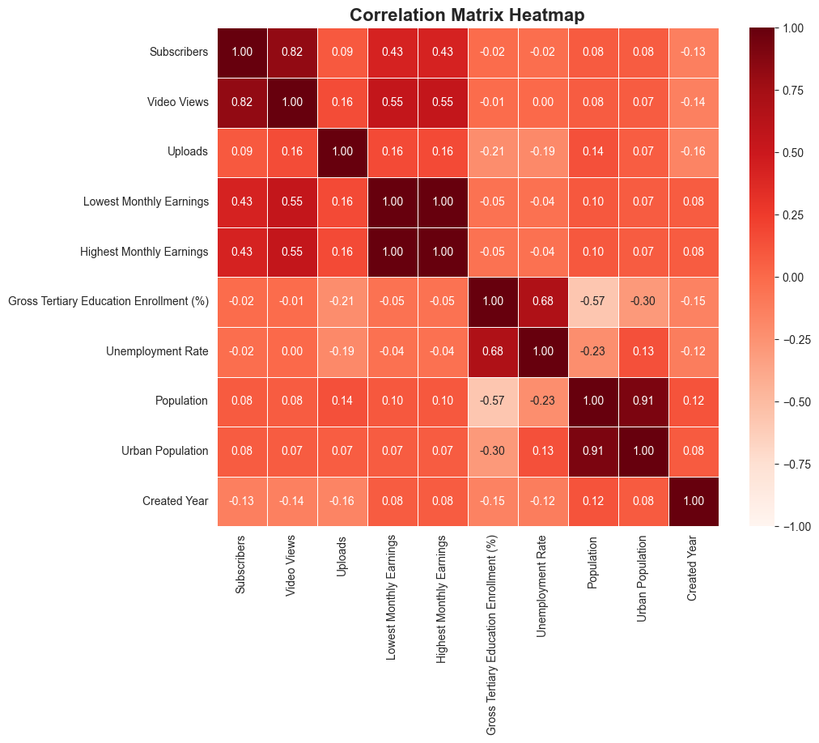

```python
#Visualization heatmap

plt.figure(figsize= (10,8))
plt.title('Correlation Matrix Heatmap', fontweight = 'heavy', fontsize = 16)
sb.heatmap(correlation, annot= True,

cmap= 'Reds',

vmin= -1, vmax= 1,

linecolor = 'white', linewidths = 0.5,

fmt = '.2f'
)

plt.show()
```

There is high correlation between attributes, particularly the high correlation between Subscribers and Video Views. However, these two attributes has moderate-to-low correlation with other attributes, even no correlation with Uploads Two variables Lowest Monthly Earnings and Highest Monthly Earnings are highly correlated (100%).

### 1. What are top 10 Youtubers who have the most subscribers and top 10 Youtubers who have the highest amount of views?

```python
#Statistics by Subscribers #Select columns to show output

select_columns = ['Youtuber', 'Subscribers']

#Filter dataframe for top 10 most subscribers Youtuber channels
top_10_subs = youtube[select_columns].head(10)

#Convert 'Subscriber' in millions

top_10_subs['Subscribers (million)'] = (top_10_subs['Subscribers'] / 1000000).astype('int')
top_10_subs = top_10_subs[['Youtuber','Subscribers (million)']]

#Show dataframe
top_10_subs
```

|  | Youtuber | Subscribers (million) |
| --- | --- | --- |
| 0 | T-Series | 245 |
| 1 | MrBeast | 166 |
| 2 | Cocomelon - Nursery Rhymes | 162 |
| 3 | SET India | 159 |
| 4 | Kids Diana Show | 112 |
| 5 | PewDiePie | 111 |
| 6 | Like Nastya | 106 |
| 7 | Vlad and Niki | 98 |
| 8 | Zee Music Company | 96 |
| 9 | WWE | 96 |

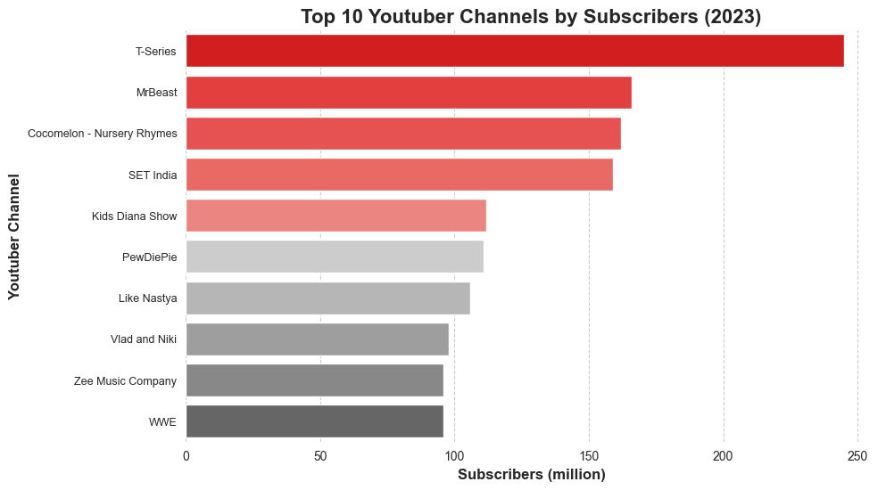

```python
#Visualization
plt.figure(figsize= (10,6))
plt.title('Top 10 Youtuber Channels by Subscribers (2023)',
          fontweight = 'heavy', fontsize = 16)
sb.barplot(top_10_subs,x = 'Subscribers (million)' ,y = 'Youtuber', palette= youtube_color_barchart_10 )
plt.xlabel('Subscribers (million)',fontweight = 'heavy', fontsize = 12)

plt.ylabel('Youtuber Channel',fontweight = 'heavy', fontsize = 12)
plt.yticks(size = 9)
sb.despine(left=True, bottom=True)
plt.grid(axis = 'x', linestyle ='--')
plt.show()
```

```python
#Statistics by Video Views
#Select columns to show output

select_columns = ['Youtuber', 'Video Views']
#Filter dataframe for top 10 most video view Youtuber channels
youtube_videoviews = youtube[select_columns]
top_10_views = youtube_videoviews.sort_values(by = 'Video Views', ascending= False).head(10)
#Convert 'Video Views' in billions
top_10_views['Video Views (billion)'] = (top_10_views['Video Views'] / 1000000000).astype('int')
top_10_views = top_10_views[['Youtuber', 'Video Views (billion)']].sort_values(by= 'Video Views (billion)', ascending = False)
#Show dataframe
top_10_views
```

|  | Youtuber | Video Views (billion) |
| --- | --- | --- |
| 0 | T-Series | 228 |
| 2 | Cocomelon - Nursery Rhymes | 164 |
| 3 | SET India | 148 |
| 12 | Sony SAB | 101 |
| 4 | Kids Diana Show | 93 |
| 6 | Like Nastya | 90 |
| 9 | WWE | 77 |
| 7 | Vlad and Niki | 77 |
| 17 | Zee TV | 73 |
| 22 | Colors TV | 61 |

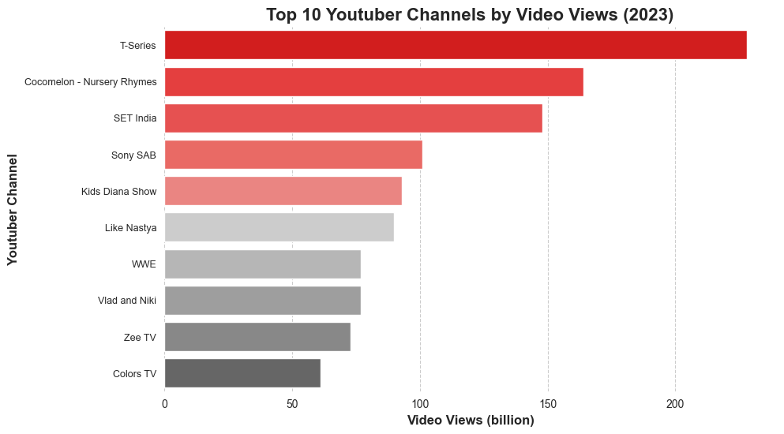

```python
#Visualization
plt.figure(figsize= (10,6))
plt.title('Top 10 Youtuber Channels by Video Views (2023)',fontweight = 'heavy', fontsize = 16)
sb.barplot(top_10_views,x = 'Video Views (billion)' ,y = 'Youtuber', palette= youtube_color_barchart_10 )
plt.xlabel('Video Views (billion)',fontweight = 'heavy', fontsize = 12)
plt.ylabel('Youtuber Channel',fontweight = 'heavy', fontsize = 12)
plt.yticks(size = 9)
sb.despine(left=True, bottom=True)
plt.grid(axis = 'x', linestyle ='--')
plt.show()
```

Overall, from the two bar charts above, we observe that 7 out of the 10 channels with the highest number of subscribers also appear in the top 10 channels with the highest video views.

=> This raises the question: Is there a correlation between the number of subscribers and the number of views? Let's delve deeper into the relationship between these two metrics in the next section.

### 2. Does it mean that a Youtube channel owning a high number of subscribers is associated with a high amount of views?

```python
#Statistics Subscriber (million), Video Views (billion) & Uploads (k.)
#Select columns to show output

select_columns = ['Youtuber', 'Subscribers', 'Video Views', 'Uploads']

#Filter dataframe by select_columns
youtube_corr_statistics = youtube[select_columns]
#Convert 'Subscriber' in millions
youtube_corr_statistics['Subscribers (million)'] = (youtube_corr_statistics['Subscribers']/1000000).astype('int')
#Convert 'Video Views' in millions
youtube_corr_statistics['Video Views (billion)'] = (youtube_corr_statistics['Video Views']/1000000000).astype('int')
#Convert 'Uploads' in thousand
youtube_corr_statistics['Uploads (k.)'] = (youtube_corr_statistics['Uploads']/1000)
youtube_corr_statistics = youtube_corr_statistics[['Youtuber', 'Subscribers (million)', 'Video Views (billion)', 'Uploads (k.)']]
#Show dataframe
youtube_corr_statistics.head()
```

|  | Youtuber | Subscribers (million) | Video Views (billion) | Uploads (k.) |
| --- | --- | --- | --- | --- |
| 0 | T-Series | 245 | 228 | 20.082 |
| 1 | MrBeast | 166 | 28 | 0.741 |
| 2 | Cocomelon - Nursery Rhymes | 162 | 164 | 0.966 |
| 3 | SET India | 159 | 148 | 116.536 |
| 4 | Kids Diana Show | 112 | 93 | 1.111 |

```python
youtube_corr_statistics['Video Views (billion)'].mean()
```

```
10.711180124223603
```

```python
youtube_corr_statistics['Subscribers (million)'].mean()
```

```
22.27225672877847
```

```python
per_subs = round(np.percentile(youtube_corr_statistics['Subscribers (million)'], 95))
per_views = round(np.percentile(youtube_corr_statistics['Video Views (billion)'], 95))

print('95% youtube channels have the total Subscribers below:', per_subs, 'million')
print('95% youtube channels have the total Subscribers above:', per_views, 'billion')
```

```
95% youtube channels have the total Subscribers below: 46 million
95% youtube channels have the total Subscribers above: 28 billion
```

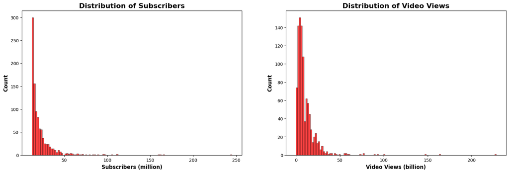

```python
fig, (ax1, ax2) = plt.subplots(1,2, figsize = (20,6))
sb.histplot(youtube_corr_statistics['Subscribers (million)'], color= 'red',ax = ax1)
ax1.set_title('Distribution of Subscribers', fontweight = 'heavy', fontsize = 16)
ax1.set_xlabel('Subscribers (million)', fontweight = 'heavy', fontsize = 12)
ax1.set_ylabel('Count', fontweight = 'heavy', fontsize = 12)
sb.histplot(youtube_corr_statistics['Video Views (billion)'], color= 'red', ax = ax2)
ax2.set_title('Distribution of Video Views', fontweight = 'heavy', fontsize = 16)
ax2.set_xlabel('Video Views (billion)', fontweight = 'heavy', fontsize = 12)
ax2.set_ylabel('Count', fontweight = 'heavy', fontsize = 12)
```

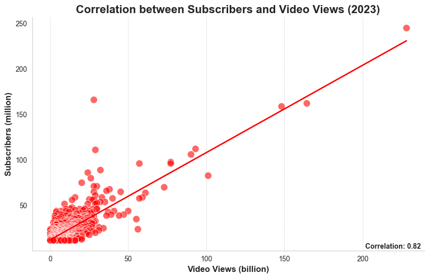

```python
# Calculate the correlation coefficient
correlation = youtube_corr_statistics['Subscribers (million)'].corr(youtube_corr_statistics['Video Views (billion)'])

# Set scaling factor of circle size
scaling_factor = 2

# Calculate the size of circles
sizes = youtube_corr_statistics['Video Views (billion)'] * scaling_factor

# Chart
plt.figure(figsize= (10,6))
plt.title('Correlation between Subscribers and Video Views (2023)', fontweight = 'heavy', fontsize = 16 )
sb.scatterplot(data= youtube_corr_statistics, x='Video Views (billion)', y='Subscribers (million)', color = 'red', alpha = 0.6, s=100)
sb.regplot(data= youtube_corr_statistics, x='Video Views (billion)', y='Subscribers (million)', scatter=False, ci=None, line_kws={"color": "red", "linestyle": "-", "linewidth": 2})
plt.xlabel('Video Views (billion)', fontweight = 'heavy', fontsize = 12)
plt.ylabel('Subscribers (million)', fontweight = 'heavy', fontsize = 12)
plt.grid(True, which = 'both', linestyle = '--', linewidth = 0.5)

sb.despine(left=False, bottom=False)
plt.grid(axis = 'y', linestyle ='')
# Note correlation
plt.annotate(f'Correlation: {correlation:.2f}', xy = (0.85, 0.01),
xycoords = 'axes fraction',
fontsize = 10, weight = 'bold')
plt.show()
```

From the correlation matrix table, Subscribers and Views have a high correlation rate up to 82%. The scatter plot chart shows in more detail the positive relationship between these two variables (the more subscribers a YouTube channel has, the more views it will have). Looking at the scatter plot chart, the distribution of the majority of data is concentrated in a range significantly lower than the top 10 mentioned in question 1, while only a few channels have a larger number of subscribers and views than the rest. Specifically, through the histogram chart, the data shows that up to 95% of YouTube channels have less than 46 million subscribers and less than 28 billion views.

=> This leads to the conclusion that:

- In fact, there is a significant positive relationship between subscribers and views. At the same time, this also implies that only a few channels truly outperform the rest in terms of success (measured based on the number of Subscribers and Views).
- So the question is what factors contribute to the success of a YouTube channel?

### 3. Does it mean that a Youtube channel owning a high total of uploads will lead to a high number of subscribers and amount of views?

```python
top_upload_channels = youtube[['Youtuber', 'Category', 'Uploads']].sort_values(by= 'Uploads', ascending= False).reset_index(drop=True).head(10)
top_upload_channels
```

|  | Youtuber | Category | Uploads |
| --- | --- | --- | --- |
| 0 | ABP NEWS | People & Blogs | 301308 |
| 1 | GMA Integrated News | News & Politics | 296272 |
| 2 | TV9 Bharatvarsh | People & Blogs | 293516 |
| 3 | Aaj Tak | News & Politics | 283775 |
| 4 | IndiaTV | News & Politics | 273255 |
| 5 | KOMPASTV | News & Politics | 269050 |
| 6 | Thairath Online | News & Politics | 244899 |
| 7 | News 24 | News & Politics | 211620 |
| 8 | ABS-CBN News | News & Politics | 209520 |
| 9 | TEDx Talks | Nonprofits & Activism | 200933 |

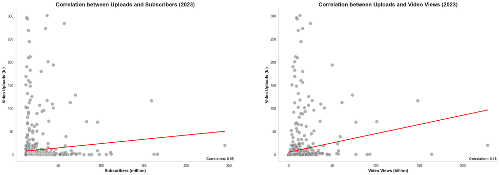

```python
fig, ax = plt.subplots(1, 2, figsize = (25,8))

#Upload & Subscribers
#Calculate the correlation coefficient
correlation_ax0 = youtube_corr_statistics['Uploads (k.)'].corr(youtube_corr_statistics['Subscribers (million)'])
# Set scaling factor of circle size
scaling_factor_ax0 = 2
# Calculate the size of circles
sizes_ax0 = youtube_corr_statistics['Subscribers (million)'] * scaling_factor_ax0
# Chart
plt.figure(figsize= (10,6))
ax[0].set_title('Correlation between Uploads and Subscribers (2023)', fontweight = 'heavy', fontsize = 16 )
sb.scatterplot(data= youtube_corr_statistics, x='Subscribers (million)', y='Uploads (k.)', color = 'gray',alpha=0.6, s=100, ax=ax[0])
sb.regplot(data= youtube_corr_statistics, x='Subscribers (million)', y='Uploads (k.)', scatter=False, ci=None,line_kws={"color": "red", "linestyle": "-", "linewidth": 2}, ax=ax[0])
ax[0].set_xlabel('Subscribers (million)', fontweight = 'heavy', fontsize = 12)
ax[0].set_ylabel('Video Uploads (k.)', fontweight = 'heavy', fontsize = 12)
ax[0].spines['top'].set_visible(False) #remove x-axis on the top
ax[0].spines['right'].set_visible(False) #remove x-axis on the right
# Note correlation
ax[0].annotate(f'Correlation: {correlation_ax0:.2f}', xy = (0.87, 0.01), xycoords = 'axes fraction', fontsize = 10, weight = 'bold')

#Uploads & Video Views # Calculate the correlation coefficient
correlation_ax1 = youtube_corr_statistics['Uploads (k.)'].corr(youtube_corr_statistics['Video Views (billion)'])
# Set scaling factor of circle size
scaling_factor_ax1 = 2
# Calculate the size of circles
sizes_ax1 = youtube_corr_statistics['Video Views (billion)'] * scaling_factor
# Chart
plt.figure(figsize= (10,6))
ax[1].set_title('Correlation between Uploads and Video Views (2023)', fontweight = 'heavy', fontsize = 16 )
sb.scatterplot(data= youtube_corr_statistics, x='Video Views (billion)', y='Uploads (k.)', color = 'gray',alpha=0.6, s=100, ax=ax[1])
sb.regplot(data= youtube_corr_statistics, x='Video Views (billion)', y='Uploads (k.)', scatter=False, ci=None, line_kws={"color": "red", "linestyle": "-", "linewidth": 2}, ax=ax[1])
ax[1].set_xlabel('Video Views (billion)', fontweight = 'heavy', fontsize = 12)
ax[1].set_ylabel('Video Uploads (k.)', fontweight = 'heavy', fontsize = 12)
# ax[1].grid(True, which = 'both', linestyle = '--', linewidth = 0.5)
# Note correlation
ax[1].annotate(f'Correlation: {correlation_ax1:.2f}', xy = (0.87, 0.01), xycoords = 'axes fraction', fontsize = 10, weight = 'bold')
ax[1].spines['top'].set_visible(False)
ax[1].spines['right'].set_visible(False)
plt.show();
```

### 4. What are some categories of Youtube channels which have the most uploads?

```python
#Statistics by Category
#Group by lots of feature by Category
statis_category = youtube.groupby('Category').agg({'Category' : 'count', 'Uploads' : 'sum', 'Subscribers' : 'sum', 'Video Views' : 'sum' })
#Rename count feature
statis_category = statis_category.rename(columns= {'Category' : 'Count of Category'}).reset_index()

#Unit conversion
statis_category['Video Views (billion)'] = (statis_category['Video Views']/1000000000).astype('int')
statis_category['Subscribers (million)'] = (statis_category['Subscribers']/1000000).astype('int')
statis_category['Uploads (k.)'] = (statis_category['Uploads']/1000).astype('int')

#Select feature
statis_category = statis_category[['Category', 'Count of Category', 'Uploads (k.)','Subscribers (million)', 'Video Views (billion)']]

#Show statistics table
statis_category
```

|  | Category | Count of Category | Uploads (k.) | Subscribers (million) | Video Views (billion) |
| --- | --- | --- | --- | --- | --- |
| 0 | Autos & Vehicles | 2 | 3 | 35 | 15 |
| 1 | Comedy | 69 | 77 | 1388 | 550 |
| 2 | Education | 44 | 141 | 1175 | 691 |
| 3 | Entertainment | 235 | 2867 | 5061 | 2500 |
| 4 | Film & Animation | 44 | 127 | 1101 | 507 |
| 5 | Gaming | 92 | 403 | 1928 | 706 |
| 6 | Howto & Style | 39 | 64 | 760 | 194 |
| 7 | Movies | 2 | 7 | 51 | 15 |
| 8 | Music | 200 | 471 | 5155 | 3103 |
| 9 | News & Politics | 26 | 2924 | 536 | 270 |
| 10 | Nonprofits & Activism | 2 | 205 | 55 | 10 |
| 11 | Other | 37 | 39 | 669 | 278 |
| 12 | People & Blogs | 128 | 1212 | 2720 | 1251 |
| 13 | Pets & Animals | 4 | 17 | 72 | 44 |
| 14 | Science & Technology | 17 | 35 | 316 | 66 |
| 15 | Shows | 11 | 354 | 512 | 432 |
| 16 | Sports | 11 | 159 | 298 | 147 |
| 17 | Trailers | 2 | 13 | 78 | 33 |
| 18 | Travel & Events | 1 | 0 | 12 | 3 |

```python
#Select feature to to summary about Uploads
uploads_category = statis_category[['Category', 'Uploads (k.)']]

#Group features with counts under 300 into the general category  "other"
uploads_category.loc[uploads_category['Uploads (k.)'] < 300, 'Category'] = 'Other'
uploads_category = uploads_category.groupby(['Category'])['Uploads (k.)'].sum().reset_index().sort_values(by = 'Uploads (k.)',ascending= False)
total = sum(uploads_category['Uploads (k.)'])
uploads_category['Percent Uploads (%)'] = [round((value / total) * 100,0) for value in uploads_category['Uploads (k.)']]
uploads_category.reset_index(drop= True, inplace= True)

#Show statistics table
uploads_category
```

|  | Category | Uploads (k.) | Percent Uploads (%) |
| --- | --- | --- | --- |
| 0 | News & Politics | 2924 | 32.0 |
| 1 | Entertainment | 2867 | 31.0 |
| 2 | People & Blogs | 1212 | 13.0 |
| 3 | Other | 887 | 10.0 |
| 4 | Music | 471 | 5.0 |
| 5 | Gaming | 403 | 4.0 |
| 6 | Shows | 354 | 4.0 |

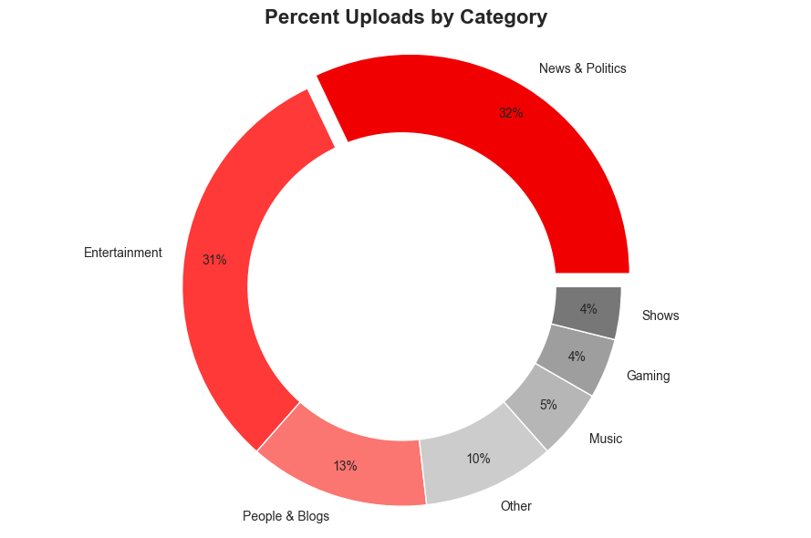

```python
labels = uploads_category['Category']
sizes = uploads_category['Uploads (k.)']

explode = [0.07, 0, 0, 0, 0, 0, 0]

plt.figure(figsize= (9,6))
plt.pie(sizes, labels= labels,
autopct='%1.0f%%',
startangle=0,
explode= explode,
colors= youtube_color_donutchart,
pctdistance=0.86)

#

# plt.legend(title = 'Category',bbox_to_anchor=(1.1, 1), labels = labels)

plt.axis('equal')
plt.title('Percent Uploads by Category', fontweight = 'heavy', fontsize = 16)
plt.tight_layout()

circle = plt.Circle(xy= (0,0), radius= .70, facecolor = 'white')

plt.gca().add_artist(circle)
plt.show();
```

- News and Politics is a content group specializing in posting videos about current events and politics including news, reports, interviews, discussions and other TV programs.The content of this section requires accuracy and continuous updating of new information, which means there is no tendency to replay them. In fact, producing content in this category often requires forces with large resources. These can be state-owned and managed organizations or high-level agencies that have an influential voice in the public for the purpose of providing reliable and useful information to viewers. This is one of YouTube's exceptions in having the highest number of videos posted regardless of views and followers.
- On the other hand, Entertainment is the leading category with a variety of topics such as: Music, games, news - entertainment, movies - TV shows,... This is almost a category that can be reserved for most individuals and organizations regardless of their scales. Anyone can capitalize on the content in this category because of its diversity of topics, thereby increasing the number of Video Uploads to approximately the highest. YouTube channels in this category are often heavily influenced by views and subscribers, which is almost the significant attribution to promoting and maintaining the development of channels built by individuals.
- Currently, the trend of producing content in the form of short videos from TikTok, Reels of Instagram, Short-form videos of Facebook,... This content model can generate a lot of Uploads in a short time but still attract a large number of modern viewers. Hot Tiktokers, KOLs,... are the leaders in producing short videos with low budgets, and those video's duration lasts from only 30 seconds to 1 minute but still receive many interactions on many platforms, including YouTube.

-> So, is the number of videos uploaded in the above 2 categories higher than the other categories because there are many YouTubers leveraging those 2 categories?

### 5. How many channels are there in each category?

```python
#Select features

count_category = statis_category[['Category', 'Count of Category']].sort_values(by = 'Count of Category', ascending = False)

# Group features with counts under 300 into the general category other

count_category.loc[count_category['Count of Category'] < 20, 'Category'] = 'Other'

count_category = count_category.groupby(['Category'])['Count of Category'].sum().reset_index().sort_values(by = 'Count of Category', ascending= False)

# total = sum(count_category['Count of Category'])
# count_category['Percent Category'] = [round((value / total) * 100,0) for value in count_category['Count of Category
count_category.reset_index(drop= True, inplace= True)
#Show statistics table
count_category
```

|  | Category | Count of Category |
| --- | --- | --- |
| 0 | Entertainment | 235 |
| 1 | Music | 200 |
| 2 | People & Blogs | 128 |
| 3 | Gaming | 92 |
| 4 | Other | 89 |
| 5 | Comedy | 69 |
| 6 | Education | 44 |
| 7 | Film & Animation | 44 |
| 8 | Howto & Style | 39 |
| 9 | News & Politics | 26 |

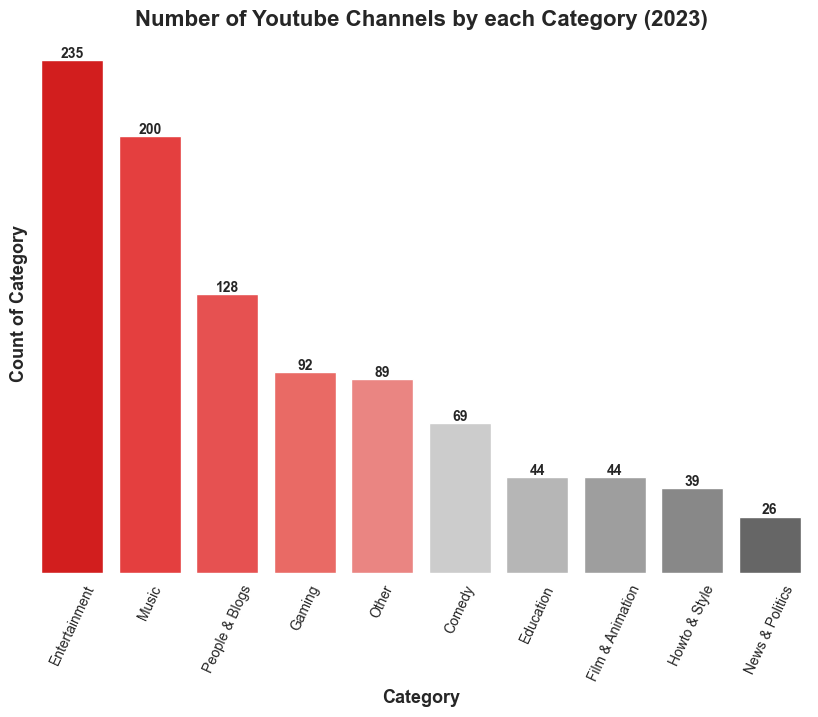

```python
sb.set_style("whitegrid",{'axes.grid' : False})

plt.figure(figsize=(10,7)) # Select data for categoies and values feature
cnt_category = count_category['Count of Category'].to_list()

#Chart
plt.title('Number of Youtube Channels by each Category (2023)', fontsize = 16, fontweight = 'heavy')
sb.barplot(data= count_category, x = 'Category', y = 'Count of Category', palette= youtube_color_barchart_10)

#Add number for each columns
for i, value in enumerate(cnt_category):
    plt.text(i, value + 1, cnt_category[i], ha = 'center', fontsize=10, fontweight = 'heavy')
sb.despine(left=True, bottom=True)
plt.grid(axis = 'y', linestyle ='--')
plt.xlabel('Category', fontsize = 13, fontweight = 'heavy')
plt.ylabel('Count of Category', fontweight = 'heavy', fontsize = 13)
plt.xticks(rotation = 65)
plt.yticks([]) #loại bỏ các tham số trên trục y
plt.show();
```

In first place, as previously mentioned, the Entertainment category has the second-highest number of video uploads, thanks to the diverse content that can be leveraged by any individual or organization. This category is a goldmine for anyone with creativity, allowing them to tap into the vast potential of the digital age.

The diversity of music genres has created extensive opportunities for music creators. The widespread popularity and ease of creation and sharing through various forms, such as covers, original compositions, or videos about music that creators are passionate about, contribute to Music being the second-largest category.

Notably, the Education, Howto & Style, and News & Politics categories are at the bottom of the rankings. These categories offer valuable content to viewers but have relatively few channels. Several reasons contribute to this, particularly for News & Politics, which requires substantial resources to maintain and develop. Additionally, the stringent requirements for content accuracy mean that only a few organizations can manage these channels. Educational channels and those providing specific how-to content require extensive knowledge and experience in their respective fields, limiting the number of individuals capable of creating, developing, and sustaining these channels.

=> Beyond these reasons, is it simply because of their diversity, popularity, or the abundance of content that can be easily created by anyone that nearly 60% of the most successful channels are concentrated in the Entertainment, Music, and People & Blogs categories? Or is this also indicative of a broader trend among YouTube users?

### 6. What are some Youtube user trends based on subscribers and view counts in each category?

```python
sub_youtuber_cate = youtube[['Youtuber', 'Category', 'Subscribers']].sort_values(by = 'Subscribers', ascending= False)

sub_youtuber_cate.head()
```

|  | Youtuber | Category | Subscribers |
| --- | --- | --- | --- |
| 0 | T-Series | Music | 245000000 |
| 1 | MrBeast | Entertainment | 166000000 |
| 2 | Cocomelon - Nursery Rhymes | Education | 162000000 |
| 3 | SET India | Shows | 159000000 |
| 4 | Kids Diana Show | People & Blogs | 112000000 |

```python
#Select feature for subscribers chart
subs_category = statis_category[['Category', 'Subscribers (million)']].sort_values(by= 'Subscribers (million)', ascending = False)
subs_category['Percent (%)'] = round((subs_category['Subscribers (million)'] / sum(subs_category['Subscribers (million)']))*100)
subs_category = subs_category.reset_index(drop=True)
subs_category
```

|  | Category | Subscribers (million) | Percent (%) |
| --- | --- | --- | --- |
| 0 | Music | 5155 | 24.0 |
| 1 | Entertainment | 5061 | 23.0 |
| 2 | People & Blogs | 2720 | 12.0 |
| 3 | Gaming | 1928 | 9.0 |
| 4 | Comedy | 1388 | 6.0 |
| 5 | Education | 1175 | 5.0 |
| 6 | Film & Animation | 1101 | 5.0 |
| 7 | Howto & Style | 760 | 3.0 |
| 8 | Other | 669 | 3.0 |
| 9 | News & Politics | 536 | 2.0 |
| 10 | Shows | 512 | 2.0 |
| 11 | Science & Technology | 316 | 1.0 |
| 12 | Sports | 298 | 1.0 |
| 13 | Trailers | 78 | 0.0 |
| 14 | Pets & Animals | 72 | 0.0 |
| 15 | Nonprofits & Activism | 55 | 0.0 |
| 16 | Movies | 51 | 0.0 |
| 17 | Autos & Vehicles | 35 | 0.0 |
| 18 | Travel & Events | 12 | 0.0 |

```python
view_youtuber_cate = youtube[['Youtuber', 'Category', 'Video Views']].sort_values(by = 'Video Views', ascending= False)

view_youtuber_cate
```

|  | Youtuber | Category | Video Views |
| --- | --- | --- | --- |
| 0 | T-Series | Music | 228000000000 |
| 2 | Cocomelon - Nursery Rhymes | Education | 164000000000 |
| 3 | SET India | Shows | 148000000000 |
| 12 | Sony SAB | Shows | 101000000000 |
| 4 | Kids Diana Show | People & Blogs | 93247040539 |
| ... | ... | ... | ... |
| 934 | Wolfoo Family | Other | 161254021 |
| 891 | Matheus Yurley | Entertainment | 140022442 |
| 829 | Vibhu 96 | Other | 20563378 |
| 880 | Calon Sarjana | Entertainment | 10664585 |
| 277 | Happy Lives | Science & Technology | 2634 |

966 rows × 3 columns

```python
#Select feature for views chart
views_category = statis_category[['Category', 'Video Views (billion)']].sort_values(by= 'Video Views (billion)', ascending = False)
views_category['Percent (%)'] = round((views_category['Video Views (billion)'] / sum(views_category['Video Views (billion)']))*100)
subs_category = subs_category.reset_index(drop=True)
views_category
```

|  | Category | Video Views (billion) | Percent (%) |
| --- | --- | --- | --- |
| 8 | Music | 3103 | 29.0 |
| 3 | Entertainment | 2500 | 23.0 |
| 12 | People & Blogs | 1251 | 12.0 |
| 5 | Gaming | 706 | 7.0 |
| 2 | Education | 691 | 6.0 |
| 1 | Comedy | 550 | 5.0 |
| 4 | Film & Animation | 507 | 5.0 |
| 15 | Shows | 432 | 4.0 |
| 11 | Other | 278 | 3.0 |
| 9 | News & Politics | 270 | 2.0 |
| 6 | Howto & Style | 194 | 2.0 |
| 16 | Sports | 147 | 1.0 |
| 14 | Science & Technology | 66 | 1.0 |
| 13 | Pets & Animals | 44 | 0.0 |
| 17 | Trailers | 33 | 0.0 |
| 0 | Autos & Vehicles | 15 | 0.0 |
| 7 | Movies | 15 | 0.0 |
| 10 | Nonprofits & Activism | 10 | 0.0 |
| 18 | Travel & Events | 3 | 0.0 |

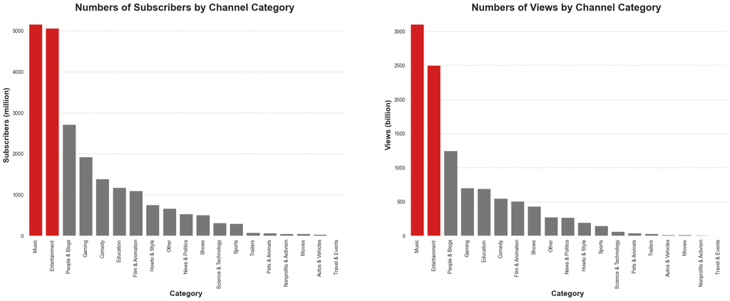

```python
sb.set_style("whitegrid",{'axes.grid' : True})

fig, ax = plt.subplots(1, 2, figsize = (25,8))
#Subscribers chart
sb.barplot(data= subs_category, x= 'Category', y = 'Subscribers (million)', ax= ax[0], palette = youtube_color_barchart_freestyle1)
ax[0].set_title('Numbers of Subscribers by Channel Category ', fontweight = 'heavy', fontsize = 20)
ax[0].set_ylabel('Subscribers (million)', fontsize = 15, fontweight = 'heavy')
ax[0].set_xlabel('Category', fontsize = 15, fontweight = 'heavy')
ax[0].grid(axis = 'y', linestyle ='--')
ax[0].spines['top'].set_visible(False)
ax[0].spines['right'].set_visible(False)
ax[0].spines['bottom'].set_visible(False)
ax[0].spines['left'].set_visible(False)
plt.sca(ax[0])
plt.xticks(rotation = 90)
#Views chart
sb.barplot(data= views_category, x= 'Category', y = 'Video Views (billion)', ax= ax[1], palette = youtube_color_barchart_freestyle1)
ax[1].set_title('Numbers of Views by Channel Category ', fontweight = 'heavy', fontsize = 20)
ax[1].set_ylabel('Views (billion)', fontsize = 15, fontweight = 'heavy')
ax[1].set_xlabel('Category', fontsize = 15, fontweight = 'heavy')
ax[1].grid(axis = 'y', linestyle ='--')
ax[1].spines['top'].set_visible(False)
ax[1].spines['right'].set_visible(False)
ax[1].spines['bottom'].set_visible(False)
ax[1].spines['left'].set_visible(False)
plt.sca(ax[1])
plt.xticks(rotation = 90)
plt.show();
```

Analysis:

With just 2 categories, Music and Entertainment, they already account for 47% of the total subscriber base and 52% of views on YouTube. Music leads in both metrics with approximately 5.2 billion subscribers and over 3100 billion views. Overall, these categories are prime entertainment genres across all platforms, amplified particularly on YouTube. These figures offer a comprehensive view of YouTube user trends.

Music:

Global Appeal: Music serves as a universal language, cherished worldwide and sought after on YouTube. Famous Artists: Many renowned artists utilize YouTube to share their music, garnering substantial attention from fans and viewers. High Quality: Music videos often feature high production values in both audio and visual aspects, providing a rich viewing experience.

Entertainment:

Diverse Content: The 'Entertainment' category on YouTube encompasses a wide array of content types, from personal vlogs and humorous videos to challenges, gaming, film reviews, and more. Creativity:

Entertainment content is notably diverse, fostering creative freedom across numerous YouTube channels.

Both categories offer viewers ways to entertain, unwind, and explore their interests, especially in the digital age where rapid transformations prioritize human entertainment needs. This makes them the two most popular categories on YouTube.

### 7. What are some interesting user interaction and behaviors in those catgories. (measured by view counts per user)

```python
#Group subscribers and video views by categories
subs_views_category = youtube.groupby('Category').agg({'Subscribers' : 'sum', 'Video Views' : 'sum'})
#Create View-to-Subscriber Ratio
subs_views_category['View-to-Subscriber Ratio'] = round(subs_views_category['Video Views'] / subs_views_category['Subscribers'])
subs_views_category.sort_values(by= 'View-to-Subscriber Ratio', ascending= False, inplace= True)
subs_views_category.reset_index( inplace= True)

#Show statistics table
subs_views_category
```

|  | Category | Subscribers | Video Views | View-to-Subscriber Ratio |
| --- | --- | --- | --- | --- |
| 0 | Shows | 512600000 | 432356612140 | 843.0 |
| 1 | Pets & Animals | 72400000 | 44866745899 | 620.0 |
| 2 | Music | 5155300000 | 3103516219048 | 602.0 |
| 3 | Education | 1175400000 | 691690418531 | 588.0 |
| 4 | News & Politics | 536400000 | 270391919347 | 504.0 |
| 5 | Sports | 298200000 | 147986290620 | 496.0 |
| 6 | Entertainment | 5061400000 | 2500154780534 | 494.0 |
| 7 | Film & Animation | 1101700000 | 507963782337 | 461.0 |
| 8 | People & Blogs | 2720900000 | 1251773521276 | 460.0 |
| 9 | Trailers | 78000000 | 33262717607 | 426.0 |
| 10 | Autos & Vehicles | 35700000 | 15003458141 | 420.0 |
| 11 | Other | 669400000 | 278191674947 | 416.0 |
| 12 | Comedy | 1388500000 | 550112774315 | 396.0 |
| 13 | Gaming | 1928500000 | 706166809255 | 366.0 |
| 14 | Movies | 51300000 | 15383255129 | 300.0 |
| 15 | Howto & Style | 760800000 | 194799530478 | 256.0 |
| 16 | Travel & Events | 12500000 | 3140883140 | 251.0 |
| 17 | Science & Technology | 316500000 | 66976747110 | 212.0 |
| 18 | Nonprofits & Activism | 55500000 | 10862911785 | 196.0 |

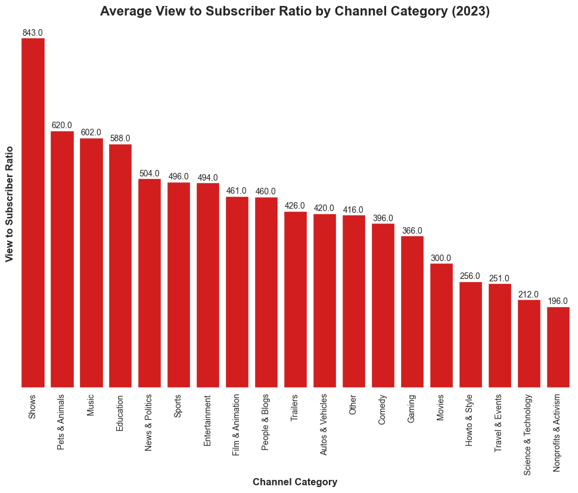

```python
sb.set_style("whitegrid",{'axes.grid' : False})

plt.figure(figsize= (12,8))

#Convert variable to a list
labels = subs_views_category['View-to-Subscriber Ratio'].to_list()

#Chart
plt.title('Average View to Subscriber Ratio by Channel Category (2023)', fontweight = 'heavy', fontsize = 16)

sb.barplot(data= subs_views_category, x = 'Category', y = 'View-to-Subscriber Ratio', color = '#f00000') #palette= yo

plt.xlabel('Channel Category', fontsize = 12, fontweight = 'heavy')

plt.ylabel('View to Subscriber Ratio', fontsize = 12, fontweight = 'heavy')

#Add label for each columns in chart
for i, value in enumerate(labels):

    plt.text(i, value + 6, labels[i], ha = 'center', fontsize=10)

sb.despine(left=True, bottom=True)
plt.xticks(rotation = 90)
plt.yticks([])
plt.show();
```

```python
print('Average views per subscriber across all categories:',round(subs_views_category['View-to-Subscriber Ratio'].mean()))
```

```
Average views per subscriber across all categories: 437
```

A high view-to-subscriber ratio indicates:

Dedicated Fan Base: Subscribers frequently return to watch new content, demonstrating a strong connection between content creators and their audience. High-Quality Content Draws Engagement: Engaging and timely topics leave a positive impression on subscribers, encouraging them to watch regularly, revisit videos, and thereby accumulate more views per subscriber.

Conversely, categories with low view-to-subscriber ratios may have several reasons:

Viral Content Focus: Channels may have a few viral videos that attract a large number of views at one time, but fail to sustain this across all uploaded content, thus not converting views into subscribers consistently.

Broad Appeal: Widely appealing content is often shared or viewed across multiple platforms besides YouTube, attracting views from casual viewers who may not necessarily subscribe.

Search-Friendly Content: Channels creating content that answers common questions (e.g., Howto & Style, Travel & Events, Science & Technology) or covers popular topics tend to have higher discoverability through YouTube or Google searches. However, once viewers find the information they need, they may not feel the need to subscribe.

These insights underscore how viewer behavior on YouTube is influenced by content quality, engagement strategies, and the ability to maintain viewer interest over time. Channels that effectively nurture subscriber loyalty and consistently produce compelling, relevant content tend to achieve higher engagement metrics.

### 8. Does the content (key terms) in the name of YouTube channels affect user views?

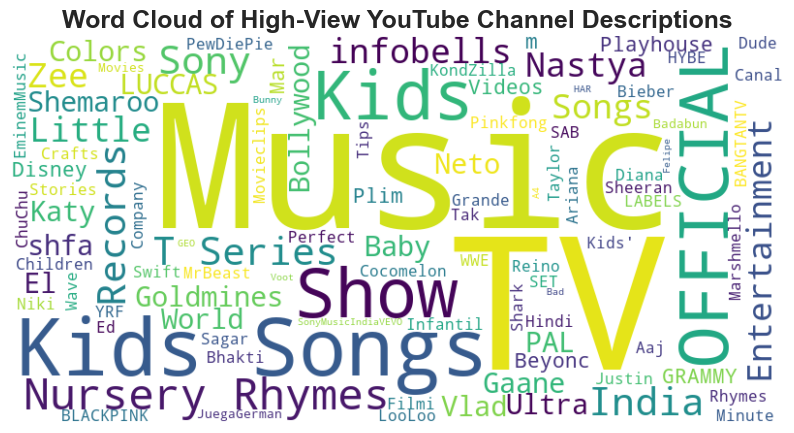

```python
# Determine the 75th percentile of video views
percentile_75th = youtube['Video Views'].quantile(0.75)
# Filter channels with views above the 75th percentile
high_view_channels = youtube[youtube['Video Views'] > percentile_75th]

# Combine the names of high-view channels into a single string
text = ' '.join(high_view_channels['Youtuber'])

# Create the word cloud
wordcloud = WordCloud(background_color = 'white', width = 800, height = 400, max_words= 100).generate(text)

# Plot the word cloud
plt.figure(figsize= (10,8))
plt.imshow(wordcloud, interpolation = 'bilinear')
plt.axis('off')
plt.title('Word Cloud of High-View YouTube Channel Descriptions', fontsize = 18, fontweight = 'heavy')
plt.show()
```

Analysis

The most prominent words in the Word Cloud chart above, such as Music, Kids, Songs, Entertainment, Nursery Rhymes, and Record, are highly relevant to the YouTube channel trends discussed in previous analyses like Music, Entertainment, and Shows.

The close correlation between the characters in YouTube channel names and their categories can be attributed to several factors:

Clear Brand Identification: Creators often want their channel names to reflect the type of content they produce. This helps potential users quickly understand the focus of the channel. A name that aligns well with the content enhances brand clarity and sets audience expectations.

Recognizability: Channels with keywords in their names that are also key terms in their category listings can improve the channel's visibility in search results.

Consistency between Name and Content: When a channel's name directly relates to its category, it provides a cohesive experience for viewers. For example, a channel named 'Action Movies' in the Movies category aligns with what users expect based on its name.

These factors underscore how the choice of words in YouTube channel names can influence brand perception, discoverability, and user engagement. Channels that effectively utilize keywords related to their content categories can enhance their appeal to target audiences and attract more views.

### 9. What countries do those top 10 youtubers come from? (Distribution of YouTube Channels by Country (2023)

```
In those countries:

9.1 What is the unemployment rate?

9.2 What is the rate of high education attainment of each country?

9.3 What is the rate of urban population in each country?
```

```python
map_chart = youtube.groupby(['Country','Abbreviation'])[['Youtuber']].count().reset_index().rename(columns={'Youtuber': 'Number of Youtube Channels'}).sort_values(by= 'Number of Youtube Channels', ascending = False)
map_chart.reset_index(drop = True, inplace= True)

map_chart['Percent'] = round((map_chart['Number of Youtube Channels'] / sum(map_chart['Number of Youtube Channels']))*100,1)

map_chart
```

|  | Country | Abbreviation | Number of Youtube Channels | Percent |
| --- | --- | --- | --- | --- |
| 0 | United States | US | 306 | 31.7 |
| 1 | India | IN | 168 | 17.4 |
| 2 | Other | Other | 113 | 11.7 |
| 3 | Brazil | BR | 61 | 6.3 |
| 4 | United Kingdom | GB | 43 | 4.5 |
| 5 | Mexico | MX | 33 | 3.4 |
| 6 | Indonesia | ID | 28 | 2.9 |
| 7 | Spain | ES | 22 | 2.3 |
| 8 | Thailand | TH | 18 | 1.9 |
| 9 | South Korea | KR | 16 | 1.7 |
| 10 | Canada | CA | 15 | 1.6 |
| 11 | Argentina | AR | 13 | 1.3 |
| 12 | Philippines | PH | 12 | 1.2 |
| 13 | Russia | RU | 11 | 1.1 |
| 14 | Colombia | CO | 11 | 1.1 |
| 15 | Australia | AU | 8 | 0.8 |
| 16 | Saudi Arabia | SA | 7 | 0.7 |
| 17 | United Arab Emirates | AE | 7 | 0.7 |
| 18 | Pakistan | PK | 6 | 0.6 |
| 19 | Germany | DE | 6 | 0.6 |
| 20 | Japan | JP | 5 | 0.5 |
| 21 | Ukraine | UA | 5 | 0.5 |
| 22 | France | FR | 5 | 0.5 |
| 23 | Turkey | TR | 4 | 0.4 |
| 24 | Sweden | SE | 4 | 0.4 |
| 25 | Netherlands | NL | 3 | 0.3 |
| 26 | Vietnam | VN | 3 | 0.3 |
| 27 | Jordan | JO | 3 | 0.3 |
| 28 | Chile | CL | 3 | 0.3 |
| 29 | Singapore | SG | 3 | 0.3 |
| 30 | Italy | IT | 2 | 0.2 |
| 31 | Iraq | IQ | 2 | 0.2 |
| 32 | Egypt | EG | 2 | 0.2 |
| 33 | Ecuador | EC | 2 | 0.2 |
| 34 | Switzerland | CH | 1 | 0.1 |
| 35 | Venezuela | VE | 1 | 0.1 |
| 36 | Afghanistan | AF | 1 | 0.1 |
| 37 | Samoa | WS | 1 | 0.1 |
| 38 | Peru | PE | 1 | 0.1 |
| 39 | Morocco | MA | 1 | 0.1 |
| 40 | Malaysia | MY | 1 | 0.1 |
| 41 | Andorra | AD | 1 | 0.1 |
| 42 | Kuwait | KW | 1 | 0.1 |
| 43 | Finland | FI | 1 | 0.1 |
| 44 | El Salvador | SV | 1 | 0.1 |
| 45 | Cuba | CU | 1 | 0.1 |
| 46 | China | CN | 1 | 0.1 |
| 47 | Barbados | BB | 1 | 0.1 |
| 48 | Bangladesh | BD | 1 | 0.1 |
| 49 | Latvia | LV | 1 | 0.1 |

```python
pip install plotly
```

```
     ━━━━━━━━━━━━━━━━━━━━━━━━━━━━━━━━━━━━━━━━ 16.4/16.4 MB 20.8 MB/s eta 0:00:0000:0100:01
```

```python
import plotly.graph_objs as go
import plotly.express as px
custom_colorscale = [
      [0, "#115f9a"],
      [0.05, "#1984c5"],
      [0.1, "#22a7f0"],
      [0.2, "#48b5c4"],
      [0.4, "#76c68f"],
      [0.6, "#a6d75b"],
      [0.7, "#c9e52f"],
      [0.8, "#d0ee11"],
      [1, "#f4f100"]
]

# Create the choropleth map with the custom colorscale
fig = px.choropleth(map_chart,
                    locations='Country',
                    locationmode='country names',
                    color='Number of Youtube Channels',
                    color_continuous_scale=custom_colorscale,
                    hover_name='Country',
                    title='Distribuiton of Channels per Country',
                    projection='equirectangular')
# Customize the colorbar title
fig.update_coloraxes(colorbar_title= 'Number of Youtube Channels')

fig.update_layout(
    title = dict(text = "Distribuiton of Channels per Country", x = 0.3),
    title_font = dict(size = 18),
    height = 630,
    width = 1100
)
# fig.update_geos( #
#showcountries = True # )
fig.update_layout(
    geo=dict(
        showcoastlines=True, coastlinecolor="White", showland=True,
        landcolor="LightGray",
        showocean=True,
        oceancolor="LightBlue"

    ))

# scattergeo_trace = go.Scattergeo( # locationmode='country names',

# locations=map_chart['Country'], # location of the countries

# text=map_chart['Abbreviation'], # Name of each country

# mode='text', # Text visibility

# showlegend=False, # hide notes

# textfont=dict(size=7, color='black', family='Arial') # text bold level

# )

# Add trace scattergeo to map
# fig.add_trace(scattergeo_trace)
```

[interactive chart not shown]

Analysis

An important aspect of this dataset reveals that up to 11% of the channels lack specific country data. This missing data could significantly impact the representation of top-ranking channels by country.

The United States and India lead globally in terms of top YouTube channels as of 2023, comprising nearly 50% of the total channels in this dataset. Specifically, the United States holds the highest position with 32%, equivalent to 306 channels, followed by India with 17%, equivalent to 168 channels.

Both countries boast large populations and robust media industries. With Hollywood in the United States and Bollywood in India being the world's leading film industries, many creators from these regions have turned to YouTube to share entertainment content.

So, what factors contribute to the United States' dominance over other countries in terms of successful YouTube channels? Let's delve into some characteristics from the data of each country in this dataset to explore this.

#### 9.1 What is the unemployment rate of each country?

```python
#Select data for 'Unemployment Rate by Country chart'

unempl_rate = youtube[['Country', 'Unemployment Rate']].sort_values(by= 'Unemployment Rate', ascending= False)

unempl_rate = unempl_rate.drop_duplicates().reset_index(drop= True)
unempl_rate.head()
```

|  | Country | Unemployment Rate |
| --- | --- | --- |
| 0 | Jordan | 14.72 |
| 1 | United States | 14.70 |
| 2 | Spain | 13.96 |
| 3 | Turkey | 13.49 |
| 4 | Iraq | 12.82 |

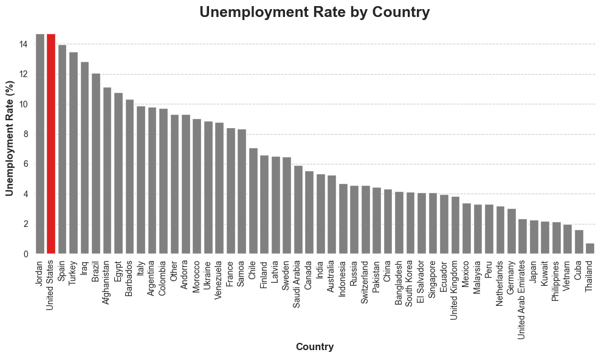

```python
#Setup color for Unemployment Rate (%) chart
unempl_colors = []
for i in range(len(unempl_rate['Country'])):
    if unempl_rate['Country'][i] == 'United States':
        unempl_colors.append('red')
    else:
        unempl_colors.append('gray')
#Chart
plt.figure(figsize = (10,6))
sb.barplot(data = unempl_rate, x = 'Country', y = 'Unemployment Rate', palette= unempl_colors)

plt.title('Unemployment Rate by Country', fontweight = 'heavy', fontsize = 18)
plt.xlabel('Country', fontweight = 'heavy', fontsize = 12)
plt.ylabel('Unemployment Rate (%)', fontweight = 'heavy', fontsize = 12)
plt.xticks(rotation = 90)
sb.despine(left=True, bottom=True)
plt.grid(axis = 'y', linestyle ='--')
plt.tight_layout()
plt.show();
```

The Impact of Unemployment Rate in a Country on the Success of YouTube Channels:

YouTube presents an opportunity for unemployed individuals with high creative potential to carve out a new path and improve their livelihoods. Those with creative abilities often have more time to focus on developing content and their channels during periods of unstable employment.

Content Creation:

Demand for Education and Job Opportunities: During times of unemployment, content related to education and job-seeking guidance becomes increasingly popular. Content creators can capitalize on these trends to help viewers learn about resume writing, interviewing skills, or professional development.

#### 9.2 What is the rate of high education attainment of each country?

```python
#Select data for 'Gross Tertiary Education Enrollment Rate by Country chart'
education_rate = youtube[['Country', 'Gross Tertiary Education Enrollment (%)']].sort_values(by= 'Gross Tertiary Education Enrollment (%)', ascending = False)#Setup color for Gross Tertiary Education Enrollment Rate (%) chart education_colors = [] for i in range(len(education_rate['Country'])):
education_rate = education_rate.drop_duplicates().reset_index(drop= True)
education_rate.head(10)
```

|  | Country | Gross Tertiary Education Enrollment (%) |
| --- | --- | --- |
| 0 | Australia | 113.1 |
| 1 | South Korea | 94.3 |
| 2 | Argentina | 90.0 |
| 3 | Spain | 88.9 |
| 4 | Chile | 88.5 |
| 5 | United States | 88.2 |
| 6 | Finland | 88.2 |
| 7 | Latvia | 88.1 |
| 8 | Netherlands | 85.0 |
| 9 | Singapore | 84.8 |

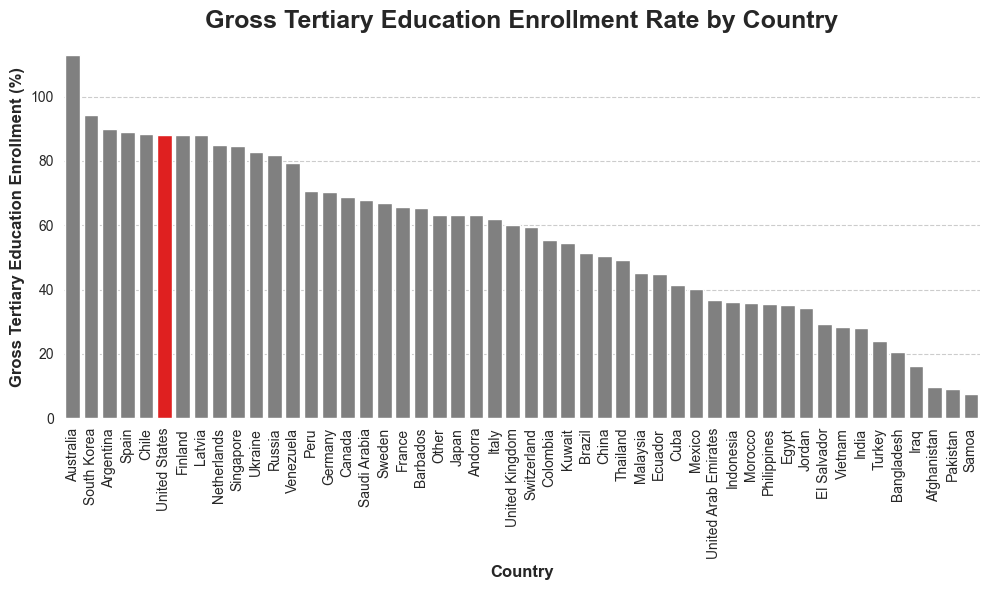

```python
#Setup color for Gross Tertiary Education Enrollment Rate (%) chart
education_colors = []
for i in range(len(education_rate['Country'])):
    if education_rate['Country'][i] == 'United States':
        education_colors.append('red')
    else:
        education_colors.append('gray')
#Chart
plt.figure(figsize = (10,6))
sb.barplot(data = education_rate, x = 'Country', y = 'Gross Tertiary Education Enrollment (%)', palette= education_colors)
plt.title('Gross Tertiary Education Enrollment Rate by Country', fontweight = 'heavy', fontsize = 18)
plt.xlabel('Country', fontweight = 'heavy', fontsize = 12)
plt.ylabel('Gross Tertiary Education Enrollment (%)', fontweight = 'heavy', fontsize = 12)
plt.xticks(rotation = 90)
sb.despine(left=True, bottom=True)
plt.grid(axis = 'y', linestyle ='--')
plt.tight_layout()
plt.show();
```

The Impact of Gross Tertiary Enrollment Ratio (GTER) on the Success of YouTube Channels:

Content Quality: YouTube channels created by individuals with higher educational attainment (GTER) are likely to produce more engaging and high-quality content in educational, research, and academic fields.

Communication and Teaching Ability: Those with higher education backgrounds often possess better communication and teaching skills, enhancing their effectiveness in delivering knowledge to viewers through online learning methods.

Target Market: The gross tertiary enrollment ratio of a country indicates a potential market for educational content categories on YouTube within that nation. Countries with higher GTER indices may generate greater demand for educational and instructional content.

#### 9.3 What is the rate of urban population in each country?

```python
#Create column 'Urbanization Rate (%)' in youtube dataset

youtube['Urbanization Rate (%)'] = round((youtube['Urban Population']/youtube['Population']) * 100,0)

urban_rate = youtube[['Country','Abbreviation', 'Urbanization Rate (%)']].sort_values(by= 'Urbanization Rate (%)', ascending = False)

urban_rate = urban_rate.drop_duplicates().reset_index(drop= True)
urban_rate.head(20)
```

|  | Country | Abbreviation | Urbanization Rate (%) |
| --- | --- | --- | --- |
| 0 | Singapore | SG | 100.0 |
| 1 | Kuwait | KW | 100.0 |
| 2 | Argentina | AR | 92.0 |
| 3 | Japan | JP | 92.0 |
| 4 | Netherlands | NL | 92.0 |
| 5 | Jordan | JO | 91.0 |
| 6 | Venezuela | VE | 88.0 |
| 7 | Sweden | SE | 88.0 |
| 8 | Chile | CL | 88.0 |
| 9 | United Arab Emirates | AE | 87.0 |
| 10 | Brazil | BR | 86.0 |
| 11 | Australia | AU | 85.0 |
| 12 | Finland | FI | 85.0 |
| 13 | United Kingdom | GB | 84.0 |
| 14 | Saudi Arabia | SA | 84.0 |
| 15 | Canada | CA | 83.0 |
| 16 | United States | US | 82.0 |
| 17 | Mexico | MX | 81.0 |
| 18 | Colombia | CO | 81.0 |
| 19 | Spain | ES | 81.0 |

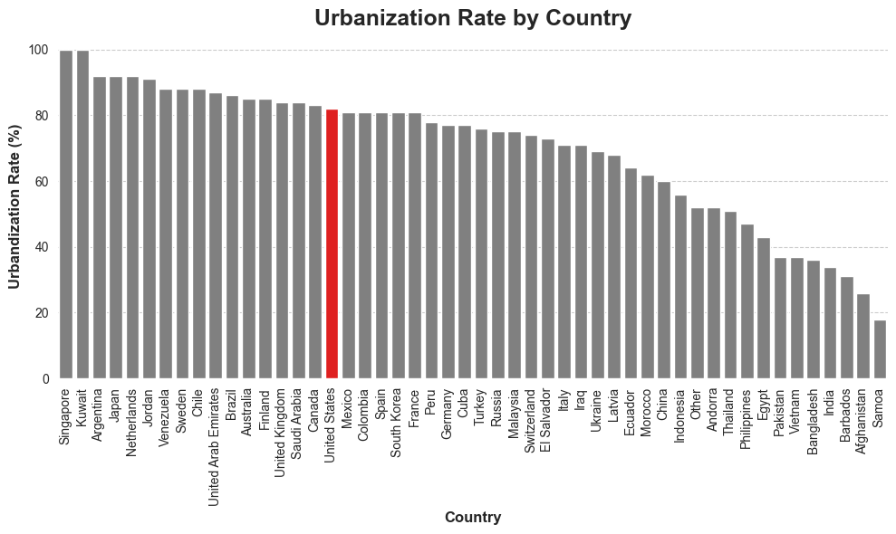

```python
#Setup color for Urbanization Rate (%) chart
urban_colors = []
for i in range(len(urban_rate['Country'])):
    if urban_rate['Country'][i] == 'United States':
        urban_colors.append('red')
    else:
        urban_colors.append('gray')
#Chart
plt.figure(figsize = (10,6))
sb.barplot(data = urban_rate, x = 'Country', y = 'Urbanization Rate (%)', palette= urban_colors)
plt.title('Urbanization Rate by Country', fontweight = 'heavy', fontsize = 18)
plt.xlabel('Country', fontweight = 'heavy', fontsize = 12)
plt.ylabel('Urbandization Rate (%)', fontweight = 'heavy', fontsize = 12)
plt.xticks(rotation = 90)
sb.despine(left=True, bottom=True)
plt.grid(axis = 'y', linestyle ='--')
plt.tight_layout()
plt.show();
```

The Impact of Urban Population Ratio on the Success of YouTube Channels:

Internet Accessibility: Urban areas typically have better internet infrastructure and connectivity compared to rural areas. Therefore, urban residents are more likely to have fast and stable internet access, facilitating easy access to and viewing of YouTube content.

Demand for Urban-related Content: Urban populations often seek content related to urban life, urban culture, and social issues pertaining to urban areas. YouTube channels that create content on these topics can attract a large viewership in urban regions.

Better Advertising Market: Urban areas tend to have a more developed advertising market. Content creators living in urban areas may have better opportunities to collaborate with advertisers and earn revenue from YouTube advertisements.

Larger Target Audience: Urban areas generally have larger populations, meaning YouTube channels have the potential to reach a larger target audience.

Conclusion:

From the observations above, we can deduce several reasons why the United States stands out as the country with the most successful YouTube channels:

According to Wikipedia and MS News, the United States is the third most populous country in the world with 336 million people. It also has a high unemployment rate of 14.7%, equivalent to 49 million people, a substantial figure.

During periods of unstable employment, exploring alternative paths becomes a viable option, including creating a personal YouTube channel. In the United States, a country diverse in all aspects of life, anyone with creativity can find content to explore on the YouTube platform.

Furthermore, the United States boasts the world's top-tier education system. With 88.2% of its population enrolled in higher education, this is a significant advantage as the workforce here possesses high educational qualifications. Individuals with higher education can create high-quality, engaging content across educational and research domains. Moreover, they have excellent communication skills, making knowledge more accessible to viewers.

Lastly, location plays a pivotal role in supporting the aforementioned points. With 82% of its population residing in urban areas where people easily access the internet and utilize multiple platforms, including YouTube, urban dwellers have broader content preferences. This environment also presents ample opportunities for collaborations and advertising contracts with companies or brands, enhancing the earning potential of YouTube channels based in urban settings.

### 10. When were most successful Youtube Channel created ?

```python
cnt_created_year = youtube.groupby('Created Year').size().to_frame().reset_index().rename(columns= {0 : 'Count'})
cnt_created_year.sort_values(by = 'Count', ascending= False)
```

|  | Created Year | Count |
| --- | --- | --- |
| 9 | 2014 | 95 |
| 1 | 2006 | 89 |
| 6 | 2011 | 81 |
| 11 | 2016 | 76 |
| 8 | 2013 | 71 |
| 10 | 2015 | 70 |
| 7 | 2012 | 68 |
| 12 | 2017 | 63 |
| 4 | 2009 | 52 |
| 2 | 2007 | 49 |
| 5 | 2010 | 48 |
| 3 | 2008 | 45 |
| 13 | 2018 | 43 |
| 14 | 2019 | 33 |
| 15 | 2020 | 30 |
| 0 | 2005 | 25 |
| 16 | 2021 | 23 |
| 17 | 2022 | 5 |

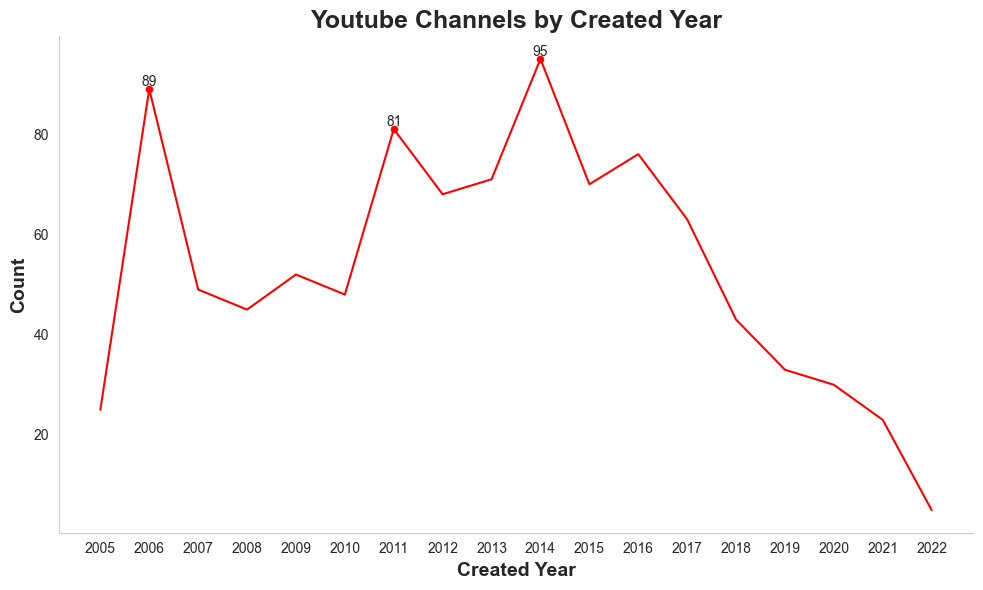

```python
sb.set_style("whitegrid",{'axes.grid' : False})
plt.figure(figsize= (12,8))

plt.figure( figsize= (10,6))
plt.title('Youtube Channels by Created Year', fontweight = 'heavy', fontsize = 18)

sb.lineplot(data = cnt_created_year, y = 'Count', x = 'Created Year', color = 'red')
label_points = [(2014, 95), (2006, 89), (2011, 81)]

for point in label_points:
    plt.text(point[0], point[1], f'{point[1]}', ha='center', va='bottom')

for point in label_points:
    x, y = point
    plt.scatter(x, y, color='red', marker='o', s=20)
plt.xlabel('Created Year', fontweight = 'heavy', fontsize = 14)
plt.ylabel('Count', fontweight = 'heavy', fontsize = 14)
sb.despine(left=False, bottom=False)

# plt.grid(axis = 'x', linestyle ='-.')

plt.tight_layout()
plt.xticks(cnt_created_year['Created Year'])
plt.show()
```

Observations:

The Birth of YouTube: Established and launched to the public in 2005, YouTube truly began to attract widespread attention and significant development by 2006. During this period, the platform was still relatively new, and the competition was not as fierce, allowing many channels to quickly rise and build a loyal fan base in its early stages.

Platform Momentum: According to Wikipedia, by 2011, there were over three billion views per day and 48 hours of video uploaded every minute. The platform grew rapidly and became an indispensable part of daily life for many people. The integration with the Google+ social network and the Chrome web browser laid the foundation for interaction between viewers and content creators. Additionally, 2011 witnessed the emergence of various content genres including entertainment, tutorials, vlogs, gaming, etc., opening up numerous opportunities for content creators on YouTube.

[output not shown]

### 11. What are the trending content creactivity of each chanel over the time?

```python
top_cnt_channel_by_year = youtube.groupby(['Created Year', 'Category'])[['Youtuber']].count().reset_index()
idx = top_cnt_channel_by_year.groupby('Created Year')['Youtuber'].idxmax()
result = top_cnt_channel_by_year.loc[idx]
result.reset_index(drop= True, inplace=True)
result.head(10)
```

|  | Created Year | Category | Youtuber |
| --- | --- | --- | --- |
| 0 | 2005 | Music | 9 |
| 1 | 2006 | Entertainment | 22 |
| 2 | 2007 | Music | 17 |
| 3 | 2008 | Music | 15 |
| 4 | 2009 | Music | 24 |
| 5 | 2010 | Music | 18 |
| 6 | 2011 | Music | 23 |
| 7 | 2012 | Music | 18 |
| 8 | 2013 | Entertainment | 19 |
| 9 | 2014 | Entertainment | 18 |

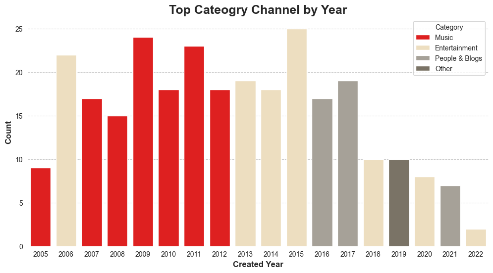

```python
plt.figure(figsize= (12,6))
sb.barplot(data = result, x = 'Created Year', y = 'Youtuber', hue = 'Category', dodge=False, palette=youtube_color_barchart_freestyle2)
plt.title('Top Cateogry Channel by Year', fontweight = 'heavy', fontsize = 18)

plt.xlabel('Created Year', fontweight = 'heavy', fontsize = 12)

plt.ylabel('Count', fontweight = 'heavy', fontsize = 12)

plt.xticks(rotation = 0, ha = 'center')

sb.despine(left=True, bottom=True)
plt.grid(axis = 'y', linestyle ='--')
plt.show()
```

```python
youtube[(youtube['Created Year'] >2012) & (youtube['Created Year'] <2016) & (youtube['Category'] == 'Entertainment')]
```

|  | Youtuber | Subscribers | Video Views | Uploads | Category | Country | Abbreviation | Lowest Monthly Earnings | Highest Monthly Earnings | Gross Tertiary Education Enrollment (%) | Unemployment Rate | Population | Urban Population | Created Year | Urbanization Rate (%) |
| --- | --- | --- | --- | --- | --- | --- | --- | --- | --- | --- | --- | --- | --- | --- | --- |
| 32 | Marshmello | 56400000 | 14696003229 | 436 | Entertainment | United States | US | 28000.0 | 448400.0 | 88.2 | 14.70 | 328239523 | 270663028 | 2015 | 82.0 |
| 51 | Voc | 44700000 | 7828610828 | 1558 | Entertainment | Brazil | BR | 12000.0 | 192100.0 | 51.3 | 12.08 | 212559417 | 183241641 | 2013 | 86.0 |
| 88 | one31 | 37500000 | 27262462114 | 117152 | Entertainment | Thailand | TH | 35200.0 | 563000.0 | 49.3 | 0.75 | 69625582 | 35294600 | 2013 | 51.0 |
| 100 | Saregama Music | 35500000 | 15657673422 | 7566 | Entertainment | India | IN | 133400.0 | 2100000.0 | 28.1 | 5.36 | 1366417754 | 471031528 | 2013 | 34.0 |
| 105 | Ryan's World | 35200000 | 55299840198 | 2453 | Entertainment | United States | US | 59700.0 | 954500.0 | 88.2 | 14.70 | 328239523 | 270663028 | 2015 | 82.0 |
| ... | ... | ... | ... | ... | ... | ... | ... | ... | ... | ... | ... | ... | ... | ... | ... |
| 903 | YoungBoy Never Broke Again | 12700000 | 13174393401 | 142 | Entertainment | United States | US | 42500.0 | 679900.0 | 88.2 | 14.70 | 328239523 | 270663028 | 2015 | 82.0 |
| 905 | Ref | 12700000 | 2709954270 | 846 | Entertainment | Other | Other | 1700.0 | 27800.0 | 63.2 | 9.30 | 436369043 | 226156206 | 2013 | 52.0 |
| 924 | Flowers Comedy | 12500000 | 11691081301 | 11907 | Entertainment | India | IN | 45000.0 | 720100.0 | 28.1 | 5.36 | 1366417754 | 471031528 | 2015 | 34.0 |
| 933 | People Vs Food | 12500000 | 1136534702 | 601 | Entertainment | United States | US | 3800.0 | 61400.0 | 88.2 | 14.70 | 328239523 | 270663028 | 2013 | 82.0 |
| 953 | Heidi and Zidane HZHtube | 12400000 | 4021409291 | 813 | Entertainment | Canada | CA | 2400.0 | 38400.0 | 68.9 | 5.56 | 36991981 | 30628482 | 2015 | 83.0 |

62 rows × 15 columns

The categories of Music and Entertainment have prominently led the trends in successful YouTube channels, appearing in 14 out of 18 years since the platform's inception and development.

We can observe a clear shift in channel creation trends from music to entertainment:

Period from 2007 to 2012: The trend in channel creation focused heavily on the music category. During this period, as the internet boom unfolded, music also rapidly transitioned from physical formats like CDs and tapes to online music platforms such as Apple's iTunes in 2003 and Spotify in 2006. In 2005, YouTube emerged as a pivotal moment in music history, providing a platform where individuals could enjoy on-demand videos from anywhere with an internet connection. A video format incorporating both audio and visuals, free of charge to users, directly competed with established music listening platforms.

Period from 2013 to 2022: The trend in channel creation primarily shifted towards the Entertainment category, although not as dominantly as the preceding music trend. Following the initial three years of music trend development, YouTube began to gain popularity. Increasing user numbers drove channel creation on the platform beyond just music development. Entertainment emerged as an essential need in daily life. The robust growth of entertainment content on the YouTube platform peaked in channel success numbers around 2015.

As time progressed, user trends diversified further. During the strong development phase of entertainment trends, the People & Blogs category emerged as a significant trend. From 2016 to 2017, the integration of social networks and video content propelled the growth of channels featuring People & Blogs content. Everyday life content, vlogs, and personal conversations attracted millions of views and followers worldwide.

```python
youtube[(youtube['Lowest Monthly Earnings']==0)& (youtube['Category'] == 'Music')]
```

|  | Youtuber | Subscribers | Video Views | Uploads | Category | Country | Abbreviation | Lowest Monthly Earnings | Highest Monthly Earnings | Gross Tertiary Education Enrollment (%) | Unemployment Rate | Population | Urban Population | Created Year | Urbanization Rate (%) |
| --- | --- | --- | --- | --- | --- | --- | --- | --- | --- | --- | --- | --- | --- | --- | --- |
| 19 | Canal KondZilla | 66500000 | 36775585925 | 2572 | Music | Brazil | BR | 0.0 | 0.00 | 51.3 | 12.08 | 212559417 | 183241641 | 2012 | 86.0 |
| 23 | T-Series Bhakti Sagar | 61000000 | 29533230328 | 13 | Music | India | IN | 0.0 | 0.04 | 28.1 | 5.36 | 1366417754 | 471031528 | 2018 | 34.0 |
| 47 | Bad Bunny | 46100000 | 30686342319 | 1 | Music | Other | Other | 0.0 | 0.00 | 63.2 | 9.30 | 436369043 | 226156206 | 2005 | 52.0 |
| 107 | T-Series Apna Punjab | 34600000 | 21306315429 | 0 | Music | Other | Other | 0.0 | 0.00 | 63.2 | 9.30 | 436369043 | 226156206 | 2020 | 52.0 |
| 116 | Desi Music Factory | 33700000 | 10189027455 | 2 | Music | Other | Other | 0.0 | 0.00 | 63.2 | 9.30 | 436369043 | 226156206 | 2018 | 52.0 |
| 166 | Maluma | 29300000 | 21226945136 | 14 | Music | Argentina | AR | 0.0 | 0.06 | 90.0 | 9.79 | 44938712 | 41339571 | 2015 | 92.0 |
| 172 | Aditya Music India | 28500000 | 25857994495 | 0 | Music | Other | Other | 0.0 | 0.00 | 63.2 | 9.30 | 436369043 | 226156206 | 2010 | 52.0 |
| 212 | Mar | 26000000 | 18597534412 | 1 | Music | Other | Other | 0.0 | 0.01 | 63.2 | 9.30 | 436369043 | 226156206 | 2008 | 52.0 |
| 369 | Linkin Park | 20400000 | 13397000296 | 0 | Music | Afghanistan | AF | 0.0 | 0.00 | 9.7 | 11.12 | 38041754 | 9797273 | 2006 | 26.0 |
| 393 | Pentatonix | 20000000 | 6033295543 | 1 | Music | Canada | CA | 0.0 | 0.00 | 68.9 | 5.56 | 36991981 | 30628482 | 2006 | 83.0 |
| 447 | Dan-Sa Daniel Saboya | 18500000 | 2908120896 | 1329 | Music | Brazil | BR | 0.0 | 0.00 | 51.3 | 12.08 | 212559417 | 183241641 | 2007 | 86.0 |
| 483 | Lil Pump | 17700000 | 4196061192 | 60 | Music | Other | Other | 0.0 | 0.00 | 63.2 | 9.30 | 436369043 | 226156206 | 2015 | 52.0 |
| 687 | Major Lazer Official | 14800000 | 9383431376 | 0 | Music | Other | Other | 0.0 | 0.00 | 63.2 | 9.30 | 436369043 | 226156206 | 2013 | 52.0 |
| 751 | Crazy Frog | 14200000 | 7946322061 | 0 | Music | Other | Other | 0.0 | 0.00 | 63.2 | 9.30 | 436369043 | 226156206 | 2005 | 52.0 |
| 913 | Jass Records | 12700000 | 5958994201 | 1 | Music | Other | Other | 0.0 | 0.00 | 63.2 | 9.30 | 436369043 | 226156206 | 2012 | 52.0 |

[output not shown]

### 12. What is the posibility of generating average earnings per month in each category?

```python
potentially_lucrative = youtube[['Category', 'Lowest Monthly Earnings', 'Highest Monthly Earnings']]
potentially_lucrative.sample(5)
```

[output not shown]

```python
potentially_lucrative['Average Monthly Earnings'] = (potentially_lucrative['Lowest Monthly Earnings'] + potentially_lucrative['Highest Monthly Earnings'])/2
potentially_lucrative.sample(5)
```

|  | Category | Lowest Monthly Earnings | Highest Monthly Earnings | Average Monthly Earnings |
| --- | --- | --- | --- | --- |
| 79 | Nonprofits & Activism | 11400.0 | 182600.0 | 97000.0 |
| 640 | People & Blogs | 16300.0 | 261500.0 | 138900.0 |
| 915 | Music | 8800.0 | 140100.0 | 74450.0 |
| 405 | Shows | 68600.0 | 1100000.0 | 584300.0 |
| 343 | Entertainment | 619.0 | 9900.0 | 5259.5 |

```python
category_avg_earnings = potentially_lucrative.groupby('Category')['Average Monthly Earnings'].mean().reset_index()
category_avg_earnings['Average Monthly Earnings (1000$)'] = (category_avg_earnings['Average Monthly Earnings'] /1000)
category_avg_earnings.sort_values(by= 'Average Monthly Earnings (1000$)', ascending= False, inplace= True)
category_avg_earnings.reset_index(drop = True, inplace= True)
category_avg_earnings
```

|  | Category | Average Monthly Earnings | Average Monthly Earnings (1000$) |
| --- | --- | --- | --- |
| 0 | Shows | 1.239268e+06 | 1239.268182 |
| 1 | Other | 6.365854e+05 | 636.585434 |
| 2 | Autos & Vehicles | 5.773250e+05 | 577.325000 |
| 3 | Sports | 4.285000e+05 | 428.500000 |
| 4 | Pets & Animals | 4.222039e+05 | 422.203875 |
| 5 | Film & Animation | 3.924375e+05 | 392.437468 |
| 6 | Education | 3.766251e+05 | 376.625104 |
| 7 | Comedy | 3.550899e+05 | 355.089877 |
| 8 | News & Politics | 3.414123e+05 | 341.412293 |
| 9 | Entertainment | 3.384038e+05 | 338.403767 |
| 10 | People & Blogs | 2.980894e+05 | 298.089400 |
| 11 | Music | 2.963804e+05 | 296.380446 |
| 12 | Movies | 2.415500e+05 | 241.550000 |
| 13 | Nonprofits & Activism | 2.074000e+05 | 207.400000 |
| 14 | Trailers | 1.922500e+05 | 192.250000 |
| 15 | Gaming | 1.440938e+05 | 144.093812 |
| 16 | Science & Technology | 1.073393e+05 | 107.339324 |
| 17 | Howto & Style | 1.024930e+05 | 102.493030 |
| 18 | Travel & Events | 6.590000e+04 | 65.900000 |

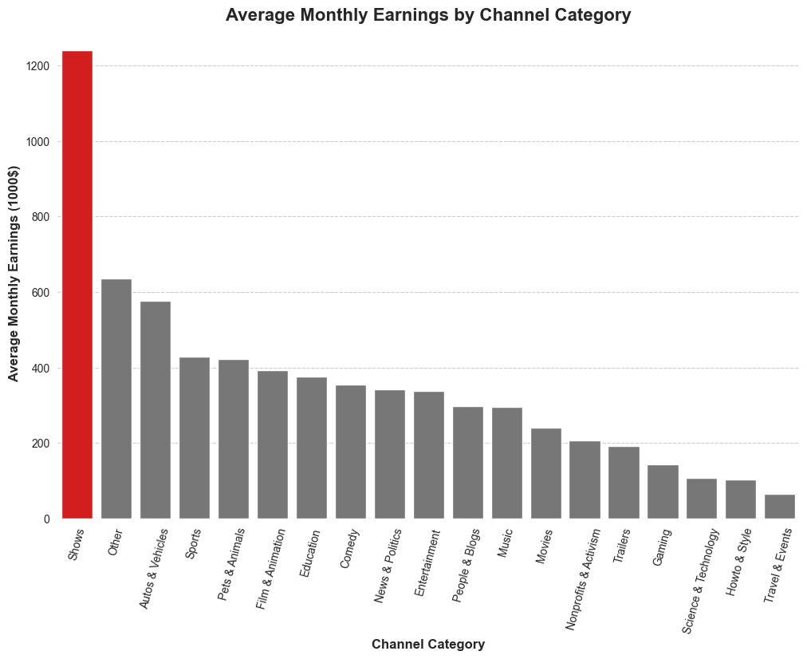

```python
plt.figure(figsize=(12,8))
sb.barplot(data= category_avg_earnings, x = 'Category', y = 'Average Monthly Earnings (1000$)', palette= youtube_color_barchart_freestyle3)
plt.title('Average Monthly Earnings by Channel Category', fontweight = 'heavy', fontsize = 16)
sb.despine(left=True, bottom=True)
plt.grid(axis = 'y', linestyle ='--')
plt.xlabel('Channel Category', fontweight = 'heavy', fontsize = 12)
plt.ylabel('Average Monthly Earnings (1000$)', fontweight = 'heavy', fontsize = 12)
plt.xticks(rotation = 75)
plt.show()
```

Some channels with unidentified categories rank second in average monthly earnings. This anomaly arises from missing category data. However, as it constitutes only about 3% of the data, its impact on other categories is minimal and can be overlooked in the chart analysis.

Despite previous analyses indicating that Music and Entertainment are the most popular categories, they surprisingly fall into the mid to lower range in terms of earning potential. This disparity raises questions about the relationship between viewership, popularity, and revenue potential on the platform. A high-earning YouTube channel does not necessarily rely on user views alone but may benefit from diverse revenue streams.

### 13. Does it mean that a higher number of views will result in higher earnings?

```python
#Select 4 columns (Youtuber, Video Views, Lowest Monthly Earnings and Highest Monthly Earnings)
views_earnings = youtube[['Youtuber', 'Video Views', 'Lowest Monthly Earnings', 'Highest Monthly Earnings']]

#Add column Avg for Earnings
views_earnings['Average Monthly Earnings'] = (views_earnings['Lowest Monthly Earnings'] + potentially_lucrative['Highest Monthly Earnings'])/2

#Change the unit of Earnings (1000$)
views_earnings['Average Monthly Earnings (1000$)'] = (views_earnings['Average Monthly Earnings'] /1000).astype('int')

#Change the unit of Video Views (billion)
views_earnings['Video Views (billion)'] = (views_earnings['Video Views'] /1000000000).astype('int')

#Select final column
views_earnings = views_earnings[['Youtuber', 'Video Views (billion)', 'Average Monthly Earnings (1000$)']]

#Show statistics table
views_earnings.head()
```

|  | Youtuber | Video Views (billion) | Average Monthly Earnings (1000$) |
| --- | --- | --- | --- |
| 0 | T-Series | 228 | 4782 |
| 1 | MrBeast | 28 | 2868 |
| 2 | Cocomelon - Nursery Rhymes | 164 | 4196 |
| 3 | SET India | 148 | 3877 |
| 4 | Kids Diana Show | 93 | 1541 |

```python
# Calculate the correlation coefficient
correlation = views_earnings['Average Monthly Earnings (1000$)'].corr(views_earnings['Video Views (billion)'])
```

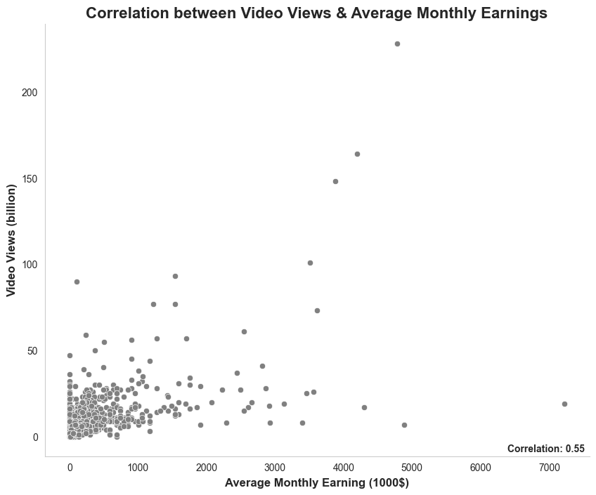

```python
#Edit chart
sb.set_style("whitegrid",{'axes.grid' : False})
plt.figure(figsize=(10,8))
sb.scatterplot(data = views_earnings, x = 'Average Monthly Earnings (1000$)', y = 'Video Views (billion)', color = 'grey')
plt.title('Correlation between Video Views & Average Monthly Earnings', fontsize = 16, fontweight = 'heavy')
plt.xlabel('Average Monthly Earning (1000$)', fontsize = 12, fontweight = 'heavy')
plt.ylabel('Video Views (billion)', fontsize = 12, fontweight = 'heavy')
sb.despine(left=False, bottom=False)
plt.grid(axis = 'y', linestyle ='')
# Note correlation
plt.annotate(f'Correlation: {correlation:.2f}',
             xy = (0.85, 0.01),
             xycoords = 'axes fraction',
             fontsize = 10,
             weight = 'bold')

plt.show()
```

Although there is a positive relationship, the correlation is not particularly strong. This suggests that merely having a high number of views does not guarantee a correspondingly high income. Other factors, such as video length, user engagement, and the placement of advertisements, can significantly impact a channel’s revenue.

The quality of the video might be more crucial than the absolute quantity (e.g., viewer retention rate, ad click-through rate, etc.). Channels that focus on creating engaging, high-quality content to attract loyal users can generate higher average monthly incomes even with fewer views.

This correlation somewhat supports the earlier point that successful YouTube channels can have diverse revenue streams. Income from merchandise sales, sponsored content, affiliate marketing, and fan contributions makes them less reliant on traditional ad revenue or user view counts.

## 6. Conclusion:

There are numerous factors that determine the success of a YouTube channel, and this analysis is based solely on the provided variables. More comprehensive data is needed to offer deeper and more useful insights for those aiming to engage with the platform.

Key Factors for YouTube Success and Trends from the Dataset:

***Determinants of Success:

YouTube channels with a strong subscriber base tend to attract more video views. Building a loyal subscriber base requires time and the effectiveness of the content provided by the channel creator. This is why channels established during key periods often achieve significant success. Overall, it is a continuous process of persistence and creativity.

Loyal Followers:

Content Selection: Categories such as Entertainment, Music, Gaming, and Comedy dominate in terms of popularity. Channels producing content in these categories often attract more viewers, especially in entertainment and music. Meanwhile, Education and How to & Style consistently hold a respectable position on the ranking, underscoring the essential nature of these content types. Shows have the highest view-to-subscriber ratio, indicating a high number of loyal followers and high-quality content. However, some categories featuring viral or search-friendly content are not performing as effectively, as they only attract unsustainable viewership. For example, the Travel & Events category illustrates this trend.

Income Sources Beyond Views:

Although there is a positive correlation between views and income, this relationship is not particularly strong. A channel's income can depend on several factors, including engagement levels, video duration, and ad placement—factors not reflected in this dataset, which limits the ability to identify the most effective income sources on the platform. However, based on the available data, shows appear to offer significant earning potential, despite music and entertainment being more popular categories.

Quality Over Quantity:

As analyzed earlier, uploading more videos does not necessarily result in more followers or views. Leading YouTubers prioritize the quality of their video content, as content is the most crucial factor. Videos must provide value to viewers, be engaging and interesting, and meet the needs of the target audience to drive interaction and satisfaction.

Consistency:

There is a strong connection between video content, channel category, and channel name. This consistency helps viewers easily find the content they need, increasing the likelihood of being recommended during searches and helping the channel reach a broader audience.

*** User Trends Across the Most Successful YouTube Channels:

Historically, during the first half of YouTube's development, music dominated user trends, maintaining prominence for six consecutive years (from 2007 to 2012). In the second half and continuing to the present, user trends have gradually shifted towards entertainment content, with the Entertainment category becoming increasingly popular.

Music and entertainment are currently the two most popular categories on the platform, consistently leading in subscriber numbers and view counts. However, the Show category has the highest view frequency per subscriber, indicating that Show content is particularly effective at attracting and retaining engaged viewers who are likely to revisit the content.

The common thread among these three categories is their ability to create diverse entertainment experiences for users. This highlights the significant role of entertainment in driving user engagement on YouTube.

*** Recommendations for Building an Effective YouTube Channel in the Future:

Identify Content and Target Audience: As the world evolves and topics diversify, finding a content niche that aligns with your creative strengths and identifying a related target audience is the first step to establishing a presence on the platform.

Quality Content: As emphasized throughout the analysis, content quality is paramount. A channel featuring engaging videos that meet viewer needs is more likely to convert views into subscriptions.

Viewer Interaction: Engaging with viewers by responding to comments, interacting on social media, and building a supportive community is crucial for developing a loyal subscriber base.

Cross-Platform Sharing: Sharing videos and content (release schedules, demo videos, teasers, etc.) on linked social media platforms can enhance visibility and reach targeted audiences.

SEO (Search Engine Optimization): Optimizing both video content and descriptions can improve the likelihood of appearing in YouTube search results.

Personal Branding: Continuously updating and expanding your knowledge in your primary content area is essential for in-depth development. Leveraging your creativity to produce unique and standout content is key to distinguishing your channel from others.

Time and Patience: Building a channel and amassing a large, loyal audience is a long-term process. Persistence and continuous effort to stay current with trends are vital qualities for any aspiring YouTuber.